# Data Mining / Prospecção de Dados

## Diogo F. Soares and Sara C. Madeira, 2020/21

# Project 2 - Clustering

## Logistics

*Read Carefully*

**Students should work in teams of 2 or 3 people**.

Individual projects might be allowed (with valid justification), but will not have better grades for this reason.

The quality of the project will dictate its grade, not the number of people working.

**The project's solution should be uploaded in Moodle before the end of `April, 18th (23:59)`.**

Students should **upload a `.zip` file** containing all the files necessary for project evaluation. Groups should be registered in [Moodle](https://moodle.ciencias.ulisboa.pt/mod/groupselect/view.php?id=139096) and the zip file should be identified as `PDnn.zip` where `nn` is the number of your group.

**It is mandatory to produce a Jupyter notebook containing code and text/images/tables/etc describing the solution and the results. Projects not delivered in this format will not be graded. You can use `PD_202021_P2.ipynb`as template. In your `.zip` folder you should also include an HTML version of your notebook with all the outputs** (File > Download as > HTML).

**Decisions should be justified and results should be critically discussed.**

*Project solutions containing only code and outputs without discussions will achieve a maximum grade 10 out of 20.*

## Dataset and Tools

In this project you should use [Python 3](https://www.python.org), [Jupyter Notebook](http://jupyter.org) and **[Scikit-learn](http://scikit-learn.org/stable/)**.

The dataset to be analysed is **`medulloblastoma_genes.csv`**. It includes 76 samples of medulloblastoma (MB) with respective expression levels of 54.675 genes measured in children with ages between 3 and 16 years. Medulloblastoma is a malignant childhood brain tumour comprising four discrete subgroups.

In this project you will consider the labels of the samples included in the `labels.csv` file where samples are labelled as MB-CL or Other. In this case, we have 51 samples of classic medulloblastoma (MB-CL) and 25 other types (namely: 6 desmoplastic nodular, 17 anaplastic and 2 medullomyoblastoma).

In `medulloblastoma_genes.csv` each line represents a sample and each column represents a gene.

**The goal is to cluster samples and (ideally) find "MB-CL" groups and "Other MB" groups.**

## Team Identification

**GROUP 11**

Students:

- Diogo Azevedo - 55773
- Lucas Silva - 55922
- Rodrigo Cassanheira - 55781

## 0.1 Imports

```python
import pandas as pd
import  numpy as np
import seaborn as sns
from sklearn.preprocessing import StandardScaler
from sklearn.preprocessing import StandardScaler, normalize
from sklearn.decomposition import PCA
from sklearn.feature_selection import VarianceThreshold
from sklearn.cluster import AgglomerativeClustering
from sklearn.cluster import KMeans
from sklearn import metrics
from sklearn.metrics import pairwise_distances
from sklearn.feature_selection import VarianceThreshold
import matplotlib.pyplot as plt
import seaborn as sns
from sklearn.metrics.cluster import contingency_matrix
from sklearn.cluster import OPTICS, DBSCAN
from sklearn.cluster import AffinityPropagation, SpectralClustering

medula_path = './medulloblastoma_genes.csv'
labels_path = './labels.csv'
```

## 0.2 Aux Function

```python
def load_data(fname):
    df = pd.read_csv(fname)
    return df
```

```python
# Function to obtain the V Measure metric of clusters the user pretends
# Receives as input the data in format of DataFrame, and the method used to calculate the clusters,
# The method is a column on the DataFrame with the respective cluster it was predicted by the clustering algorithm
# Returns as output the value of the V Measure

def get_vmeasure(data,method):
    # Encode labels
    data.loc[data['class'] == 'MB-CL', ['class']] = 1
    data.loc[data['class'] == 'Other', ['class']] = 0
    labels_true = data['class']

    labels = data[method]

    return metrics.v_measure_score(labels_true, labels)
```

```python
# Function to obtain the Number of instances of each class (MB-CL & Other) in the clusters
# Receives as input the DataFrame and the col used
# Returns as output a dictionary with the instances of each class in the clusters

def get_cluster_dict(df,col):
    count = {}
    for i in df[col].unique():
        if df.iloc[i].loc['class'] == 'MB-CL' or df.iloc[i].loc['class'] == 'Other':
            count[i] = {'MB-CL': df.loc[df['class'] == 'MB-CL'].loc[df[col] == i].shape[0], 'Other': df.loc[df['class'] == 'Other'].loc[df[col] == i].shape[0]}
        else:
            count[i] = {'MB-CL': df.loc[df['class'] == 1].loc[df[col] == i].shape[0], 'Other': df.loc[df['class'] == 0].loc[df[col] == i].shape[0]}

    return count
```

```python
# Function to obtain the silhouette score for the method of clustering chosen
# Receives as input the DataFrame, the columns used (without target column), and the method used to calculate the clusters
# Returns as output the value of the silhouette score

def get_silhuette_score(df,cols,method):
    return metrics.silhouette_score(df[cols].to_numpy(), df[method].to_numpy(), metric='euclidean')
```

```python
# Function to obtain the dictionary with the instances of each class in the clusters, and the scores calculated (Silhouette Coefficient & V Measure) using K Means clustering algorithm
# Receives as input the data in format of DataFrame, the columns used to fit the model (doesn´t contain the target column), and the value of k to be used by the algorithm
# Returns as output a dictionary with the instances of each class in the clusters in the format specified in the project rules, and the scores of the metrics calculated

def perform_Kmeans(df,cols,k):

    # Cluster
    kmeans = KMeans(n_clusters=k, random_state=0).fit(df[cols])
    lables = 'kmeans_'+str(k)
    df[lables] = kmeans.labels_

    # Scores
    scores = {}
    scores['silhouette'] = metrics.silhouette_score(df[cols].to_numpy(), df[lables].to_numpy(), metric='euclidean')
    scores['vmeasure'] = get_vmeasure(df,lables)

    return get_cluster_dict(df, lables), scores
```

```python
# Function to obtain the dictionary with the instances of each class in the clusters, and the scores calculated (Silhouette Coefficient & V Measure) using Hierarchical Clustering Algorithm
# Receives as input the data in format of DataFrame, the columns used to fit the model (doesn´t contain the target column), and the number of clusters to be used by the algorithm
# Returns as output a dictionary with the instances of each class in the clusters in the format specified in the project rules, and the scores of the metrics calculated

def perform_HCA(df, cols, linkage, n_clusters):

    # Cluster
    hca = AgglomerativeClustering(linkage = linkage, n_clusters=n_clusters).fit(df[cols])
    lables = 'hca_' + linkage + '_' + str(n_clusters)
    df[lables] = hca.labels_

    # Scores
    scores = {}
    scores['silhouette'] = metrics.silhouette_score(df[cols].to_numpy(), df[lables].to_numpy(), metric='euclidean')
    scores['vmeasure'] = get_vmeasure(df,lables)

    return get_cluster_dict(df, lables), scores
```

```python
# Function to obtain the dictionary with the instances of each class in the clusters, and the scores calculated (Silhouette Coefficient & V Measure) using AffinityPropagation clustering algorithm
# Receives as input the data in format of DataFrame, and the columns used to fit the model (doesn´t contain the target column)
# Returns as output a dictionary with the instances of each class in the clusters in the format specified in the project rules, and the scores of the metrics calculated

def perform_AP(df, cols):
    #Cluster
    ap = AffinityPropagation(random_state=0).fit(df[cols])
    lables = 'ap_'
    df[lables] = ap.labels_

    #Scores
    scores = {}
    scores['silhouette'] = metrics.silhouette_score(df[cols].to_numpy(), df[lables].to_numpy(), metric='euclidean')
    scores['vmeasure'] = get_vmeasure(df,lables)

    return get_cluster_dict(df, lables), scores
```

```python
# Function to obtain the dictionary with the instances of each class in the clusters, and the scores calculated (Silhouette Coefficient & V Measure) using SpectralClustering clustering algorithm
# Receives as input the data in format of DataFrame, the columns used to fit the model (doesn´t contain the target column), and the value of clusters to be used by the algorithm
# Returns as output a dictionary with the instances of each class in the clusters in the format specified in the project rules, and the scores of the metrics calculated

def perform_SC(df, cols, n_clusters):
    #Cluster
    sc = SpectralClustering(n_clusters=n_clusters, random_state=0).fit(df[cols])
    labels = 'sc_' + str(n_clusters)
    df[labels] = sc.labels_

    # Scores
    scores = {}
    scores['silhouette'] = metrics.silhouette_score(df[cols].to_numpy(), df[labels].to_numpy(), metric='euclidean')
    scores['vmeasure'] = get_vmeasure(df,labels)

    return get_cluster_dict(df, labels), scores
```

```python
# Function to plot the various values of the silhouette obtained using the clustering algorithms, to check which value of k is the best
# Receives as input the data in format of DataFrame, the columns used to fit the model, and the linkage used (not always necessary if we decide to use K Means)
# Fits the data provided or with the HCA or with K Means, with k between 2 and 7
# Shows the lineplot of the various values of the silhouette by given algorithm

def plot_silhouette(df, cols, linkage = ''):
    scores = []
    ks = []
    for k in range(2,7):
        if linkage != '':
            scores.append(perform_HCA(df, cols, linkage, k)[1])
            ks.append(k)
        else:
            scores.append(perform_Kmeans(df, cols, k)[1])
            ks.append(k)

    scores_df = pd.DataFrame({'scores': scores, 'k': ks})
    sns.lineplot(data=scores_df, x="k", y="scores")
```

```python
def initialize_cluster_variables(clusters):
    cluster_test = []
    clusters += 1
    for k in range(2,clusters):
        dict_test = {}
        for i in range(0,k):
            dict_test[str(i)] = []
        dict_test['score'] = []
        cluster_test.append(dict_test)

    return cluster_test
```

```python
# Function to obtain the X_variance (DataFrame after using the Feature selector that removes all low-variance features)
# Receives as input the threshold, so Features with a training-set variance lower than this threshold will be removed, and the Data to be transformed
# Returns as output a DataFrame with reduced selected features and the target column of the instances, and it's already normalized

def get_X_variance(treshold, X):
    X_cols = X.drop(columns = ['class', 'samples']).columns

    var_filter = VarianceThreshold(treshold)
    var_filter.fit(X[X_cols])
    X_variance = var_filter.transform(X[X_cols])
    X_variance = X[X_cols][X_cols[var_filter.get_support(indices=True)]]
    X_variance_cols = X_variance.columns
    X_variance[X_variance_cols] = normalize(X_variance[X_variance_cols])
    X_variance

    # Add Labels
    X_variance = pd.concat([X_variance, labels['class']], axis=1)

    return X_variance
```

```python
# Function to obtain the X_PCA, we take a high dimensional data and project it to a lower dimensional one.
# Receives as input the threshold, so Features with a training-set variance lower than this threshold will be removed, and the Data to be transformed
# Returns as output a DataFrame with reduced selected features and the target column of the instances, and it's already normalized

def get_X_PCA(treshold, medula):

    features = medula.drop(columns = ['samples','class']).columns
    # Separating out the features
    X = medula.loc[:, features].values
    # Separating out the target
    y = medula.loc[:,['samples']].values
    # Standardizing the features
    X = StandardScaler().fit_transform(X)

    #Definir variancia Explicada
    pca = PCA(treshold)
    principalComponents = pca.fit_transform(X)
    X_PCA = pd.DataFrame(data = principalComponents, columns = [f"PC{i + 1}" for i in range(len(principalComponents[0]))])
    X_PCA = pd.concat([X_PCA, labels[['class']]], axis = 1)
    X_PCA_cols = X_PCA.drop(columns = ['class'], axis = 1).columns
    X_PCA[X_PCA_cols] = StandardScaler().fit_transform(X_PCA[X_PCA_cols])
    X_PCA[X_PCA_cols] = normalize(X_PCA[X_PCA_cols])

    return X_PCA, pca
```

```python
# Function to obtain the best scores for the K Means and HCA
# Where it forms a new dataframe (Variance or PCA), and performs for the different parameters
# calculates the scores for the metrics we use to evaluate the best clusters
# Returns as output 2 Dataframes with the best scores, one of the silhouette score and the other of the V Measure

def get_best_scores(var_min, var_max, step, df, X):

    kmeans_scores_best_s = []
    hca_average_scores_best_s = []
    hca_complete_scores_best_s = []
    hca_single_scores_best_s = []
    hca_ward_scores_best_s = []

    kmeans_scores_best_v = []
    hca_average_scores_best_v = []
    hca_complete_scores_best_v = []
    hca_single_scores_best_v = []
    hca_ward_scores_best_v = []

    x = []

    for i in np.arange(var_min, var_max, step):

        x.append(round(i,2))
        if df == 'X_variance':
            X_df = get_X_variance(i, X)
            cols = X_df.drop(columns = ['class']).columns
        elif df == 'X_PCA':
            X_df = get_X_PCA(i, X)[0]
            cols = X_df.drop(columns = ['class']).columns

        kmeans_scores_s = []
        hca_average_scores_s = []
        hca_complete_scores_s = []
        hca_single_scores_s = []
        hca_ward_scores_s = []

        kmeans_scores_v = []
        hca_average_scores_v = []
        hca_complete_scores_v = []
        hca_single_scores_v = []
        hca_ward_scores_v = []

        for k in range(2,7):
            clusters, kmeans = perform_Kmeans(X_df,cols,k)
            clusters, hca_average = perform_HCA(X_df, cols, linkage = "average", n_clusters = k)
            clusters, hca_complete = perform_HCA(X_df, cols, linkage = "complete", n_clusters = k)
            clusters, hca_single = perform_HCA(X_df, cols, linkage = "single", n_clusters = k)
            clusters, hca_ward = perform_HCA(X_df, cols, linkage = "ward", n_clusters = k)

            kmeans_scores_s.append(kmeans['silhouette'])
            hca_average_scores_s.append(hca_average['silhouette'])
            hca_complete_scores_s.append(hca_complete['silhouette'])
            hca_single_scores_s.append(hca_single['silhouette'])
            hca_ward_scores_s.append(hca_ward['silhouette'])

            kmeans_scores_v.append(kmeans['vmeasure'])
            hca_average_scores_v.append(hca_average['vmeasure'])
            hca_complete_scores_v.append(hca_complete['vmeasure'])
            hca_single_scores_v.append(hca_single['vmeasure'])
            hca_ward_scores_v.append(hca_ward['vmeasure'])

        # Append best score of all the Ks
        kmeans_scores_best_s.append(max(kmeans_scores_s))
        hca_average_scores_best_s.append(max(hca_average_scores_s))
        hca_complete_scores_best_s.append(max(hca_complete_scores_s))
        hca_single_scores_best_s.append(max(hca_single_scores_s))
        hca_ward_scores_best_s.append(max(hca_ward_scores_s))

        kmeans_scores_best_v.append(max(kmeans_scores_v))
        hca_average_scores_best_v.append(max(hca_average_scores_v))
        hca_complete_scores_best_v.append(max(hca_complete_scores_v))
        hca_single_scores_best_v.append(max(hca_single_scores_v))
        hca_ward_scores_best_v.append(max(hca_ward_scores_v))

        # Score to df
        scores_df_s = pd.DataFrame(
        {'kmeans_scores_best': kmeans_scores_best_s,
         'hca_average_scores_best': hca_average_scores_best_s,
         'hca_complete_scores_best': hca_complete_scores_best_s,
         'hca_single_scores_best': hca_single_scores_best_s,
         'hca_ward_scores_best': hca_ward_scores_best_s,
         'variance': x})

        scores_df_v = pd.DataFrame(
        {'kmeans_scores_best': kmeans_scores_best_v,
         'hca_average_scores_best': hca_average_scores_best_v,
         'hca_complete_scores_best': hca_complete_scores_best_v,
         'hca_single_scores_best': hca_single_scores_best_v,
         'hca_ward_scores_best': hca_ward_scores_best_v,
         'variance': x})

    return scores_df_s, scores_df_v
```

```python
# Function to plot the best scores of the clusters calculated before
# Receives as input a DataFrame with scores, and the labels to compare
# Shows a plot of the different clustering algorithm scores

def plot_best_scores(scores_df, x_label, y_label):
    # multiple line plots
    plt.figure(figsize = (15,8))
    plt.xlabel(x_label)
    plt.ylabel(y_label)
    plt.plot( 'variance', 'kmeans_scores_best', data=scores_df, marker='', color='tab:blue', linewidth=2)
    plt.plot( 'variance', 'hca_average_scores_best', data=scores_df, marker='', color='tab:orange', linewidth=2)
    plt.plot( 'variance', 'hca_complete_scores_best', data=scores_df, marker='', color='tab:green', linewidth=2)
    plt.plot( 'variance', 'hca_single_scores_best', data=scores_df, marker='', color='tab:red', linewidth=2)
    plt.plot( 'variance', 'hca_ward_scores_best', data=scores_df, marker='', color='tab:purple', linewidth=2)
    # show legend
    plt.legend()
    # show graph
    plt.show()
```

```python
# Function to plot all the different HCA clusters depending on the linkage used
# In order to compare the best one which should be chosen by the best values  obtained

def plot_hca_models(n_clusters):

    ks = []

    var_complete_scores_s = []
    var_single_scores_s = []
    var_ward_scores_s = []
    var_average_scores_s = []

    PCA_complete_scores_s = []
    PCA_single_scores_s = []
    PCA_ward_scores_s = []
    PCA_average_scores_s = []

    var_complete_scores_v = []
    var_single_scores_v = []
    var_ward_scores_v = []
    var_average_scores_v = []

    PCA_complete_scores_v = []
    PCA_single_scores_v = []
    PCA_ward_scores_v = []
    PCA_average_scores_v = []


    for k in range(2,n_clusters + 1):

        var_average_scores_s.append(perform_HCA(X_variance, X_variance_cols, linkage = "average", n_clusters = k)[1]['silhouette'])
        var_complete_scores_s.append(perform_HCA(X_variance, X_variance_cols, linkage = "complete", n_clusters = k)[1]['silhouette'])
        var_single_scores_s.append(perform_HCA(X_variance, X_variance_cols, linkage = "single", n_clusters = k)[1]['silhouette'])
        var_ward_scores_s.append(perform_HCA(X_variance, X_variance_cols, linkage = "ward", n_clusters = k)[1]['silhouette'])

        PCA_average_scores_s.append(perform_HCA(X_PCA, X_PCA_cols, linkage = "average", n_clusters = k)[1]['silhouette'])
        PCA_complete_scores_s.append(perform_HCA(X_PCA, X_PCA_cols, linkage = "complete", n_clusters = k)[1]['silhouette'])
        PCA_single_scores_s.append(perform_HCA(X_PCA, X_PCA_cols, linkage = "single", n_clusters = k)[1]['silhouette'])
        PCA_ward_scores_s.append(perform_HCA(X_PCA, X_PCA_cols, linkage = "ward", n_clusters = k)[1]['silhouette'])

        var_average_scores_v.append(perform_HCA(X_variance, X_variance_cols, linkage = "average", n_clusters = k)[1]['vmeasure'])
        var_complete_scores_v.append(perform_HCA(X_variance, X_variance_cols, linkage = "complete", n_clusters = k)[1]['vmeasure'])
        var_single_scores_v.append(perform_HCA(X_variance, X_variance_cols, linkage = "single", n_clusters = k)[1]['vmeasure'])
        var_ward_scores_v.append(perform_HCA(X_variance, X_variance_cols, linkage = "ward", n_clusters = k)[1]['vmeasure'])

        PCA_average_scores_v.append(perform_HCA(X_PCA, X_PCA_cols, linkage = "average", n_clusters = k)[1]['vmeasure'])
        PCA_complete_scores_v.append(perform_HCA(X_PCA, X_PCA_cols, linkage = "complete", n_clusters = k)[1]['vmeasure'])
        PCA_single_scores_v.append(perform_HCA(X_PCA, X_PCA_cols, linkage = "single", n_clusters = k)[1]['vmeasure'])
        PCA_ward_scores_v.append(perform_HCA(X_PCA, X_PCA_cols, linkage = "ward", n_clusters = k)[1]['vmeasure'])

        ks.append(k)

    scores_df = pd.DataFrame({'var_average_scores_v': var_average_scores_v,
                              'var_complete_scores_v':var_complete_scores_v,
                              'var_single_scores_v':var_single_scores_v,
                              'var_ward_scores_v':var_ward_scores_v,
                              'PCA_average_scores_v':PCA_average_scores_v,
                              'PCA_complete_scores_v':PCA_complete_scores_v,
                              'PCA_single_scores_v':PCA_single_scores_v,
                              'PCA_ward_scores_v':PCA_ward_scores_v,

                              'var_average_scores_s': var_average_scores_s,
                              'var_complete_scores_s':var_complete_scores_s,
                              'var_single_scores_s':var_single_scores_s,
                              'var_ward_scores_s':var_ward_scores_s,
                              'PCA_average_scores_s':PCA_average_scores_s,
                              'PCA_complete_scores_s':PCA_complete_scores_s,
                              'PCA_single_scores_s':PCA_single_scores_s,
                              'PCA_ward_scores_s':PCA_ward_scores_s,

                              'k': ks})

    # multiple line plots
    fig, axs = plt.subplots(ncols=2,figsize=(25,8))

    axs[0].plot( 'k', 'var_complete_scores_s', data=scores_df, marker='', color='tab:orange', linewidth=2)
    axs[0].plot( 'k', 'var_ward_scores_s', data=scores_df, marker='', color='bisque', linewidth=2)
    axs[0].plot( 'k', 'PCA_ward_scores_s', data=scores_df, marker='', color='tab:blue', linewidth=2)
    axs[0].plot( 'k', 'PCA_single_scores_s', data=scores_df, marker='', color='lightblue', linewidth=2)

    axs[0].plot( 'k', 'var_single_scores_s', data=scores_df, marker='', color='bisque', linewidth=2)
    axs[0].plot( 'k', 'var_average_scores_s', data=scores_df, marker='', color='firebrick', linewidth=2)
    axs[0].plot( 'k', 'PCA_average_scores_s', data=scores_df, marker='', color='tab:cyan', linewidth=2)
    axs[0].plot( 'k', 'PCA_complete_scores_s', data=scores_df, marker='', color='lightblue', linewidth=2)
    axs[0].legend()

    axs[1].plot( 'k', 'var_complete_scores_v', data=scores_df, marker='', color='tab:orange', linewidth=2)
    axs[1].plot( 'k', 'var_ward_scores_v', data=scores_df, marker='', color='bisque', linewidth=2)
    axs[1].plot( 'k', 'PCA_single_scores_v', data=scores_df, marker='', color='lightblue', linewidth=2)
    axs[1].plot( 'k', 'PCA_ward_scores_v', data=scores_df, marker='', color='tab:blue', linewidth=2)

    axs[1].plot( 'k', 'var_average_scores_v', data=scores_df, marker='', color='firebrick', linewidth=2)
    axs[1].plot( 'k', 'var_single_scores_v', data=scores_df, marker='', color='bisque', linewidth=2)
    axs[1].plot( 'k', 'PCA_average_scores_v', data=scores_df, marker='', color='tab:cyan', linewidth=2)
    axs[1].plot( 'k', 'PCA_complete_scores_v', data=scores_df, marker='', color='lightblue', linewidth=2)
    axs[1].legend()

    axs[0].set_title('Silhouette Scores')
    axs[1].set_title('Vmeasure Scores')

    # show graph
    plt.show()
```

```python
# Function to plot the various clustering models scores, for a given number of clusters
# For the different methods, HCA or K Means

def plot_models(cluster_mode, n_clusters, dfs, cols):
    raw_df_scores_s = []
    X_variance_scores_s = []
    X_PCA_scores_s = []

    raw_df_scores_v = []
    X_variance_scores_v = []
    X_PCA_scores_v = []

    ks = []

    for k in range(2,n_clusters + 1):

        if cluster_mode == 'kmeans':
            raw_df_scores_s.append(perform_Kmeans(dfs[0], cols[0], k)[1]['silhouette'])
            X_variance_scores_s.append(perform_Kmeans(dfs[1], cols[1], k)[1]['silhouette'])
            X_PCA_scores_s.append(perform_Kmeans(dfs[2], cols[2], k)[1]['silhouette'])

            raw_df_scores_v.append(perform_Kmeans(dfs[0], cols[0], k)[1]['vmeasure'])
            X_variance_scores_v.append(perform_Kmeans(dfs[1], cols[1], k)[1]['vmeasure'])
            X_PCA_scores_v.append(perform_Kmeans(dfs[2], cols[2], k)[1]['vmeasure'])


        if cluster_mode == 'hca_average':
#             raw_df_scores.append(perform_HCA(X_PCA, X_PCA_cols, linkage = "average", n_clusters = k)[1])
            X_variance_scores_s.append(perform_HCA(dfs[0], cols[0], linkage = "average", n_clusters = k)[1]['silhouette'])
            X_PCA_scores_s.append(perform_HCA(dfs[1], cols[1], linkage = "average", n_clusters = k)[1]['silhouette'])

            X_variance_scores_v.append(perform_HCA(dfs[0], cols[0], linkage = "average", n_clusters = k)[1]['vmeasure'])
            X_PCA_scores_v.append(perform_HCA(dfs[1], cols[1], linkage = "average", n_clusters = k)[1]['vmeasure'])


        if cluster_mode == 'hca_complete':
#             raw_df_scores.append(perform_HCA(X_PCA, X_PCA_cols, linkage = "average", n_clusters = k)[1])
            X_variance_scores_s.append(perform_HCA(dfs[0], cols[0], linkage = "complete", n_clusters = k)[1]['silhouette'])
            X_PCA_scores_s.append(perform_HCA(dfs[1], cols[1], linkage = "complete", n_clusters = k)[1]['silhouette'])

            X_variance_scores_v.append(perform_HCA(dfs[0], cols[0], linkage = "complete", n_clusters = k)[1]['vmeasure'])
            X_PCA_scores_v.append(perform_HCA(dfs[1], cols[1], linkage = "complete", n_clusters = k)[1]['vmeasure'])

        if cluster_mode == 'hca_single':
#             raw_df_scores.append(perform_HCA(X_PCA, X_PCA_cols, linkage = "average", n_clusters = k)[1])
            X_variance_scores_s.append(perform_HCA(dfs[0], cols[0], linkage = "single", n_clusters = k)[1]['silhouette'])
            X_PCA_scores_s.append(perform_HCA(dfs[1], cols[1], linkage = "single", n_clusters = k)[1]['silhouette'])

            X_variance_scores_v.append(perform_HCA(dfs[0], cols[0], linkage = "single", n_clusters = k)[1]['vmeasure'])
            X_PCA_scores_v.append(perform_HCA(dfs[1], cols[1], linkage = "single", n_clusters = k)[1]['vmeasure'])


        if cluster_mode == 'hca_ward':
#             raw_df_scores.append(perform_HCA(X_PCA, X_PCA_cols, linkage = "average", n_clusters = k)[1])
            X_variance_scores_s.append(perform_HCA(dfs[0], cols[0], linkage = "ward", n_clusters = k)[1]['silhouette'])
            X_PCA_scores_s.append(perform_HCA(dfs[1], cols[1], linkage = "ward", n_clusters = k)[1]['silhouette'])

            X_variance_scores_v.append(perform_HCA(dfs[0], cols[0], linkage = "ward", n_clusters = k)[1]['vmeasure'])
            X_PCA_scores_v.append(perform_HCA(dfs[1], cols[1], linkage = "ward", n_clusters = k)[1]['vmeasure'])

        if cluster_mode == 'spectral':
            X_variance_scores_s.append(perform_SC(dfs[0], cols[0], n_clusters = k)[1]['silhouette'])
            X_PCA_scores_s.append(perform_SC(dfs[1], cols[1], n_clusters = k)[1]['silhouette'])

            X_variance_scores_v.append(perform_SC(dfs[0], cols[0], n_clusters = k)[1]['vmeasure'])
            X_PCA_scores_v.append(perform_SC(dfs[1], cols[1], n_clusters = k)[1]['vmeasure'])

        ks.append(k)

    if cluster_mode == 'kmeans':
        scores_df = pd.DataFrame({'X_df_scores_s': raw_df_scores_s, 'X_variance_scores_s':X_variance_scores_s, 'X_PCA_scores_s':X_PCA_scores_s,
                                  'X_df_scores_v': raw_df_scores_v, 'X_variance_scores_v':X_variance_scores_v, 'X_PCA_scores_v':X_PCA_scores_v,
                                  'k': ks})
    else:
        scores_df = pd.DataFrame({'X_variance_scores_s':X_variance_scores_s, 'X_PCA_scores_s':X_PCA_scores_s,
                                 'X_variance_scores_v':X_variance_scores_v, 'X_PCA_scores_v':X_PCA_scores_v,
                                  'k': ks})

    # multiple line plots
    fig, axs = plt.subplots(ncols=2,figsize=(20,5))

#     axs[0].figure(figsize = (10,8))
#     axs[0].xlabel("Number of Clusters")
#     axs[0].ylabel("Silhouette Score")
    if cluster_mode == 'kmeans':
        axs[0].plot( 'k', 'X_df_scores_s', data=scores_df, marker='', color='tab:green', linewidth=2)
    axs[0].plot( 'k', 'X_variance_scores_s', data=scores_df, marker='', color='tab:orange', linewidth=2)
    axs[0].plot( 'k', 'X_PCA_scores_s', data=scores_df, marker='', color='tab:blue', linewidth=2)
    axs[0].legend()

    if cluster_mode == 'kmeans':
        axs[1].plot( 'k', 'X_df_scores_v', data=scores_df, marker='', color='tab:green', linewidth=2)
    axs[1].plot( 'k', 'X_variance_scores_v', data=scores_df, marker='', color='tab:orange', linewidth=2)
    axs[1].plot( 'k', 'X_PCA_scores_v', data=scores_df, marker='', color='tab:blue', linewidth=2)
    axs[1].legend()

    axs[0].set_title('Silhouette Scores')
    axs[1].set_title('Vmeasure Scores')

    # show graph
    plt.show()
```

## 1. Load and Preprocess Dataset

At the end of this step you should have:

- a 76 rows × 54675 columns matrix, **X**, containing the values of the 54675 features for each of the 76 samples.
- a vector, **y**, with the 76 type of medulloblastoma, which you can use later to evaluate clustering quality.

### 1.1 Load Medula

Vamos começar por fazer load do dataframe com as diferentes features para a medula. Aqui:

- Mudamos o nome da coluna **0**, para **samples**
- Fazemos drop de possiveis rows duplicadas

```python
# Load Medula Df
X = load_data(medula_path)
X = X.rename(columns = {'Unnamed: 0': 'samples'}, inplace = False)
X = X.drop_duplicates()
X_cols = X.drop(columns = ['samples']).columns
```

```python
print(X.shape)
X.head()
```

```
(76, 54676)
```

|  | samples | 1007_s_at | 1053_at | 117_at | 121_at | 1255_g_at | 1294_at | 1316_at | 1320_at | 1405_i_at | ... | AFFX-r2-Ec-bioD-3_at | AFFX-r2-Ec-bioD-5_at | AFFX-r2-P1-cre-3_at | AFFX-r2-P1-cre-5_at | AFFX-ThrX-3_at | AFFX-ThrX-5_at | AFFX-ThrX-M_at | AFFX-TrpnX-3_at | AFFX-TrpnX-5_at | AFFX-TrpnX-M_at |
| --- | --- | --- | --- | --- | --- | --- | --- | --- | --- | --- | --- | --- | --- | --- | --- | --- | --- | --- | --- | --- | --- |
| 0 | GSM918578 | 7.59594 | 6.14440 | 4.82431 | 5.67092 | 4.14155 | 5.48935 | 6.01078 | 5.17671 | 4.83708 | ... | 10.2364 | 10.1202 | 11.5560 | 11.2308 | 6.94803 | 6.42487 | 6.70991 | 4.48639 | 4.43082 | 3.48738 |
| 1 | GSM918579 | 7.80665 | 6.19154 | 5.24439 | 5.62149 | 3.41773 | 5.70478 | 5.98896 | 3.45316 | 4.34121 | ... | 10.4747 | 10.4893 | 11.6799 | 11.3475 | 6.09785 | 4.38328 | 4.68583 | 3.40120 | 4.20916 | 4.40915 |
| 2 | GSM918580 | 7.60080 | 5.97406 | 5.36270 | 5.78598 | 3.32863 | 6.13340 | 6.09108 | 3.63495 | 5.12218 | ... | 10.8532 | 10.7125 | 11.9298 | 11.6038 | 6.49375 | 3.24259 | 3.91999 | 3.13114 | 4.02892 | 4.93087 |
| 3 | GSM918581 | 7.40141 | 5.90781 | 4.80566 | 5.97838 | 4.21804 | 5.43677 | 6.10166 | 3.37417 | 4.46706 | ... | 10.1960 | 10.2342 | 11.4141 | 11.0352 | 6.98869 | 5.42978 | 6.07764 | 3.95700 | 4.04480 | 3.32504 |
| 4 | GSM918582 | 7.54550 | 6.17877 | 5.79088 | 6.21800 | 4.61413 | 5.67710 | 4.95301 | 3.39451 | 4.51743 | ... | 10.4398 | 10.3561 | 11.4329 | 11.0906 | 6.62791 | 4.48300 | 5.89798 | 3.47816 | 4.40183 | 3.17388 |

5 rows × 54676 columns

### 1.2 Load Labels

Novamente, fazemos load do dataframe das labels e fazemos drop de possiveis rows duplicadas. Para além disto fazemos append das labels ao dataframe medula para no futuro estas serem utilizadas como o nosso *ground truth*.

```python
# Load Medula Df
labels = load_data(labels_path)
labels = labels.drop_duplicates()
X = pd.concat([X, labels['class']], axis=1)
```

```python
X.head()
```

|  | samples | 1007_s_at | 1053_at | 117_at | 121_at | 1255_g_at | 1294_at | 1316_at | 1320_at | 1405_i_at | ... | AFFX-r2-Ec-bioD-5_at | AFFX-r2-P1-cre-3_at | AFFX-r2-P1-cre-5_at | AFFX-ThrX-3_at | AFFX-ThrX-5_at | AFFX-ThrX-M_at | AFFX-TrpnX-3_at | AFFX-TrpnX-5_at | AFFX-TrpnX-M_at | class |
| --- | --- | --- | --- | --- | --- | --- | --- | --- | --- | --- | --- | --- | --- | --- | --- | --- | --- | --- | --- | --- | --- |
| 0 | GSM918578 | 7.59594 | 6.14440 | 4.82431 | 5.67092 | 4.14155 | 5.48935 | 6.01078 | 5.17671 | 4.83708 | ... | 10.1202 | 11.5560 | 11.2308 | 6.94803 | 6.42487 | 6.70991 | 4.48639 | 4.43082 | 3.48738 | MB-CL |
| 1 | GSM918579 | 7.80665 | 6.19154 | 5.24439 | 5.62149 | 3.41773 | 5.70478 | 5.98896 | 3.45316 | 4.34121 | ... | 10.4893 | 11.6799 | 11.3475 | 6.09785 | 4.38328 | 4.68583 | 3.40120 | 4.20916 | 4.40915 | MB-CL |
| 2 | GSM918580 | 7.60080 | 5.97406 | 5.36270 | 5.78598 | 3.32863 | 6.13340 | 6.09108 | 3.63495 | 5.12218 | ... | 10.7125 | 11.9298 | 11.6038 | 6.49375 | 3.24259 | 3.91999 | 3.13114 | 4.02892 | 4.93087 | MB-CL |
| 3 | GSM918581 | 7.40141 | 5.90781 | 4.80566 | 5.97838 | 4.21804 | 5.43677 | 6.10166 | 3.37417 | 4.46706 | ... | 10.2342 | 11.4141 | 11.0352 | 6.98869 | 5.42978 | 6.07764 | 3.95700 | 4.04480 | 3.32504 | MB-CL |
| 4 | GSM918582 | 7.54550 | 6.17877 | 5.79088 | 6.21800 | 4.61413 | 5.67710 | 4.95301 | 3.39451 | 4.51743 | ... | 10.3561 | 11.4329 | 11.0906 | 6.62791 | 4.48300 | 5.89798 | 3.47816 | 4.40183 | 3.17388 | Other |

5 rows × 54677 columns

### 1.3 Standardize X and Create X_s

Por fim resta-nos criar uma versão standardizada do nosso dataframe, para conseguirmos aplicar algoritmos de clustering aos nossos dados sem qualquer redução de dimensões.

```python
# Standardize raw df, for clustering
X_s = pd.DataFrame(StandardScaler().fit_transform(X[X_cols]), columns = X_cols)
X_s = pd.concat([X_s, labels['class']], axis=1)
```

```python
X_s.head()
```

|  | 1007_s_at | 1053_at | 117_at | 121_at | 1255_g_at | 1294_at | 1316_at | 1320_at | 1405_i_at | 1431_at | ... | AFFX-r2-Ec-bioD-5_at | AFFX-r2-P1-cre-3_at | AFFX-r2-P1-cre-5_at | AFFX-ThrX-3_at | AFFX-ThrX-5_at | AFFX-ThrX-M_at | AFFX-TrpnX-3_at | AFFX-TrpnX-5_at | AFFX-TrpnX-M_at | class |
| --- | --- | --- | --- | --- | --- | --- | --- | --- | --- | --- | --- | --- | --- | --- | --- | --- | --- | --- | --- | --- | --- |
| 0 | 0.438131 | -0.754400 | 0.325681 | -0.372468 | -0.309575 | 0.409900 | 1.727240 | 1.478486 | 0.863696 | 1.164623 | ... | 0.360704 | 1.352634 | 1.443734 | 0.169575 | 1.086912 | 0.791844 | 2.879534 | 1.421546 | 0.284212 | MB-CL |
| 1 | 0.890523 | -0.615514 | 0.968021 | -0.558454 | -1.058245 | 0.915104 | 1.664330 | -1.297326 | 0.087862 | -0.110198 | ... | 1.340374 | 1.744525 | 1.810688 | -0.925581 | -0.668729 | -1.255727 | -0.593524 | 0.829747 | 3.038096 | MB-CL |
| 2 | 0.448565 | -1.256264 | 1.148928 | 0.060458 | -1.150404 | 1.920260 | 1.958758 | -1.004550 | 1.309762 | 1.109693 | ... | 1.932795 | 2.534947 | 2.616604 | -0.415604 | -1.649651 | -2.030455 | -1.457828 | 0.348533 | 4.596789 | MB-CL |
| 3 | 0.020477 | -1.451454 | 0.297163 | 0.784383 | -0.230459 | 0.286594 | 1.989262 | -1.424541 | 0.284766 | 1.415216 | ... | 0.663284 | 0.903811 | 0.828684 | 0.221951 | 0.231196 | 0.152236 | 1.185266 | 0.390930 | -0.200795 | MB-CL |
| 4 | 0.329837 | -0.653137 | 1.803654 | 1.685979 | 0.179229 | 0.850192 | -1.322486 | -1.391783 | 0.363575 | 1.901509 | ... | 0.986833 | 0.963274 | 1.002885 | -0.242786 | -0.582976 | -0.029509 | -0.347220 | 1.344147 | -0.652401 | Other |

5 rows × 54676 columns

## 2. Dimensionality Reduction

As you already noticed the number of features (genes) is extremely high when compared to the number of objects to cluster (samples). In this context, you should perform dimensionality reduction, that is, reduce the number of features, in two ways:

- [**Removing features with low variance**](http://scikit-learn.org/stable/modules/feature_selection.html)
- [**Using Principal Component Analysis**](http://scikit-learn.org/stable/modules/generated/sklearn.decomposition.PCA.html)

At the end of this step you should have two new matrices with the same number of rows, each with a different number of columns (features): **X_variance** and **X_PCA**.

**Don't change X you will need it!**

### 2.1 Removing features with low variance

Para escolher o *threshold* de variancia minima a utilizar, para redução das dimensões do nosso dataframe, temos de primeiro definir o seu **critério** de escolha.

Depois de ler-mos o enunciado na sua totalidade, realizar alguns modelos e re-avaliar as nossas escolhas, decidimos que para escolher este valor, teriamos de olhar para o desempenho dos varios modelos.

Visto que a medida de desempenho sugeriada no enunciado é o **Silhouette score**, começamos por criar o plot abaixo para podermos visualizar a relação entre os scores dos modelos, e o valor do nosso **threshold**.

Os grafico abaixo é feito da seguinte forma:

1. Criamos um dataframe com um treshold definido, dependendo da iteração do ciclo. No caso abaixo, o valor do treshold começa a 0.1 e aumenta em intervalo de 0.1, até atingir o valor 6.
2. Para cada dataframe são aplicados os metodos de clustering utilizados nos pontos **3** e **4** deste notebook.
3. Para cada metodo de clustering são feitos modelos até 6 clusters
4. São guardados os melhores scores (neste caso o Silhouette score) de cada modelo, independente do valor de K.

Vamos analisar os scores para os diferentes tresholds:

```python
scores_df_s, scores_df_v = get_best_scores(0.1,6,0.1, 'X_variance', X)
```

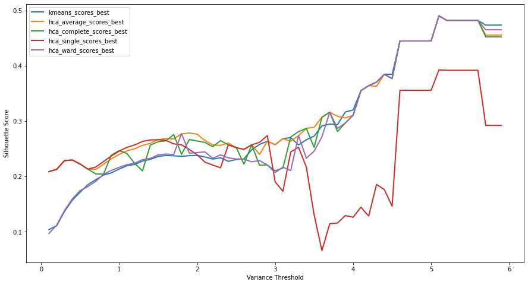

```python
plot_best_scores(scores_df_s, 'Variance Threshold', 'Silhouette Score')
```

No plot acima conseguimo ver que para valores baixos do nosso *treshold* de variancia, os modelos têm *Silhouette scores* entre 0.2 e 0.3, e que quando os valores do nosso treshold atingem valores de 4 ou acima, existe um grande salto nos *Silhouette scores*. Numa primeira iteração da escolha deste treshold decidimos usar um treshold alto de **5** com base na analise deste grafico, mas logo desde inicio achamos um pouco estranho os resultado que obtivemos aqui nesta fase de seleção, pois não acreditavamos que um numero tão pequeno de features fosse capaz de explicar os nossos dados. Mais tarde com a analise dos nossos clusters, verificamos que estes eram bastante heterogenios internamente, e foi ai que entendemos que o nosso *treshold* escolhido não era o melhor.

Com um treshold tão alto, o numero de features fica bastante reduzido, descendo das 54676 features iniciais para apenas 8. Obviamente, 8 features são incapazes de explicar corretamente os nossos dados e portanto, apesar de as distancias entre clusters aumentarem, resultando em Silhouette scores melhores, os clusters criados são incapazes de separar bem os nossos grupos.

O que decidimos então foi, visto que temos acesso as *ground truth labels*, seria mais facil fazer a escolha deste treshold, mas através da metrica **V-measure**. Conseguimos então visualizar este grafico abaixo:

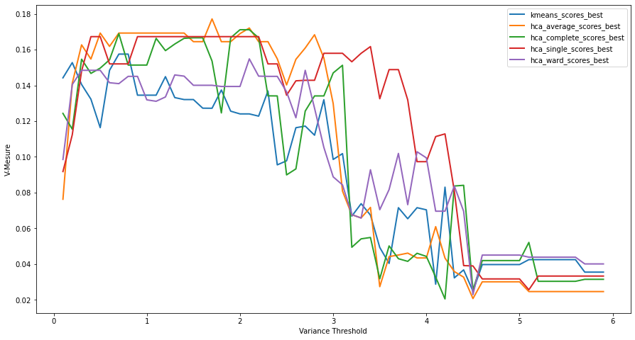

```python
plot_best_scores(scores_df_v, 'Variance Threshold', 'V-Mesure')
```

Olhando então agora para este grafico, conseguimos ver que os scores dos modelos seguem um *trend* inversa a do grafico anterior: Neste grafico, os scores dos modelos mantém-se relativamente constante até que atingem um certo *treshold*, e a partir desse treshold dá-se uma queda nos valores dos para o **V-measure** dos nossos modelos.

```python
X_variance = get_X_variance(2, X)
X_variance_cols = X_variance.drop(columns = ['class'], axis = 1).columns
X_variance.head()
```

|  | 1552489_s_at | 1553500_at | 1553705_a_at | 1553890_s_at | 1554012_at | 1554663_a_at | 1554679_a_at | 1555019_at | 1555352_at | 1555412_at | ... | 242488_at | 242699_at | 242769_at | 242881_x_at | 243278_at | 243623_at | 243929_at | 244111_at | AFFX-r2-Bs-dap-5_at | class |
| --- | --- | --- | --- | --- | --- | --- | --- | --- | --- | --- | --- | --- | --- | --- | --- | --- | --- | --- | --- | --- | --- |
| 0 | 0.038425 | 0.063652 | 0.075465 | 0.032008 | 0.027753 | 0.028914 | 0.046014 | 0.030193 | 0.064868 | 0.057954 | ... | 0.081506 | 0.049438 | 0.070489 | 0.040873 | 0.071381 | 0.034086 | 0.047064 | 0.055832 | 0.069417 | MB-CL |
| 1 | 0.046234 | 0.054316 | 0.070794 | 0.032166 | 0.046753 | 0.069205 | 0.039496 | 0.037643 | 0.042559 | 0.065085 | ... | 0.076232 | 0.056242 | 0.079178 | 0.028510 | 0.050013 | 0.051255 | 0.071139 | 0.064976 | 0.027269 | MB-CL |
| 2 | 0.036073 | 0.029862 | 0.065693 | 0.092065 | 0.027295 | 0.029108 | 0.042155 | 0.072917 | 0.040393 | 0.040874 | ... | 0.069563 | 0.062625 | 0.046974 | 0.050654 | 0.049626 | 0.046478 | 0.083691 | 0.027821 | 0.027930 | MB-CL |
| 3 | 0.040781 | 0.070464 | 0.074547 | 0.043805 | 0.040277 | 0.037462 | 0.038272 | 0.040169 | 0.047907 | 0.072486 | ... | 0.079615 | 0.045158 | 0.070622 | 0.033371 | 0.048351 | 0.030577 | 0.046061 | 0.041426 | 0.062093 | MB-CL |
| 4 | 0.034606 | 0.034042 | 0.042867 | 0.049156 | 0.031300 | 0.066155 | 0.061780 | 0.053235 | 0.066611 | 0.028924 | ... | 0.042232 | 0.059762 | 0.061854 | 0.076072 | 0.068047 | 0.032416 | 0.045754 | 0.041191 | 0.059832 | Other |

5 rows × 318 columns

Por fim, apenas por motivos de visualização, vamos criar uma versão do X_variace com as 5 features com variancia acima de 6, para vermos se alguma das combinações destas features com maior variancia apresenta uma boa separação dos tipos de medula.

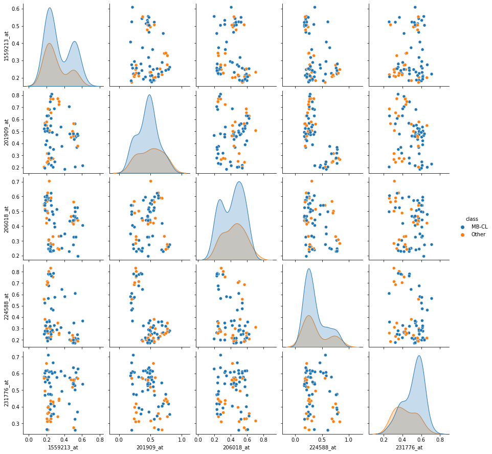

```python
visualize_X_variance = get_X_variance(6, X)
sns.pairplot(data=visualize_X_variance, hue='class')
```

Olhando para a nossa *pair matrix*, das 5 features com mais variancia conseguimos ver que não existe uma grande separação entre os grupos de medula presentes no nosso dataframe. É possivel que existam algumas possiveis relações entre variaveis que não estamos a visualizar, mas com base nesta amostra no nosso **X_variance**, prevemos que os algoritmos de cluster vão **ter algumas dificuldades** em fazer uma separação boa destes grupos.

### 2.2 PCA

Olhando agora para o PCA, tivemos o mesmo problema de escolher um *treshold* que cortava demasiada informação do nosso dataframe, que resultava depois em modelos capazes de reproduzir bons *Silhouette scores* no entanto, os clusters eram incapazes de separar bem as duas classes de medula.

Começamos por fazer plot dos varios modelos, bem como os seu *Silhouette scores* para diferentes valores de variancia explicada:

```python
scores_df_s, scores_df_v = get_best_scores(0.1,1,0.1, 'X_PCA', X)
```

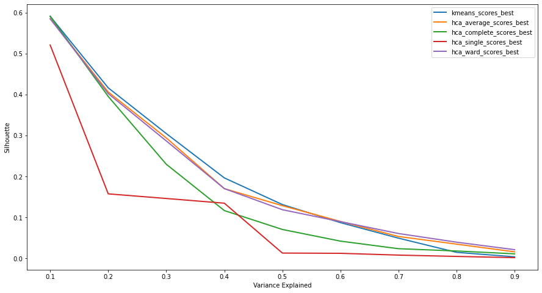

```python
plot_best_scores(scores_df_s, 'Variance Explained', 'Silhouette')
```

Para este grafico vemos claramente a *trend* de descida dos valores dos scores dos modelos, com o aumento da variancia explicada. Isto levou-nos a escolha de um valor inicial de variancia explicada igual a **0.1**.

No entanto, quando retornamos a esta fase de definição de *thresholds*, a semelhança do **X_variance**, decidimos fazer plot novo, desta vez usando como score o **V-measure**.

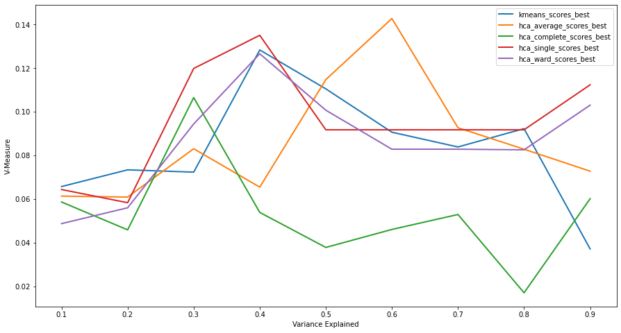

```python
plot_best_scores(scores_df_v,'Variance Explained', 'V-Measure')
```

Para este plot conseguimos ver os valores para este score começam baixos, ao contrario dos valores do plot anterior, e que tendem a subir com o aumento da variancia explicada. Conseguimos ainda ver que existem 3 valores para a **variancia explicada** que podem representar boas escolhas, dependendo do tipo de modelo que queremos usar: **0.3,0.4 e 0.6**.

- Para **0.3** vemos que existe um pico para hierarquical clustering com, *comlete* e *average linkage*.
- Para **0.4** vemos que quase todos os modelos paresentão o seu valor maximo para o score V-measure, a exeção dos modelos referidos no ponto anterior.
- Para **0.6** vemos temos o modelo de hierarquical clustering com *average linakge*, que apresenta o melhor valor de V-measure do plot inteiro.

Estavamos indecisos entre escolher o valor de **0.4** e **0.6**, no entanto, como numa das aulas de duvidas foi sugerido escolher uma valor de variancia explicada **superior a 50%**, fizemos a escolha de definir a nossa variancia explicada com valor de **0.6**.

```python
def get_X_PCA(treshold, medula):

    features = medula.drop(columns = ['class']).columns
    # Separating out the features
    X = medula.loc[:, features].values
    # Separating out the target
#     y = medula.loc[:,['samples']].values
    # Standardizing the features
    X = StandardScaler().fit_transform(X)

    #Definir variancia Explicada
    pca = PCA(treshold)
    principalComponents = pca.fit_transform(X)
    X_PCA = pd.DataFrame(data = principalComponents, columns = [f"PC{i + 1}" for i in range(len(principalComponents[0]))])
    X_PCA = pd.concat([X_PCA, labels[['class']]], axis = 1)
    X_PCA_cols = X_PCA.drop(columns = ['class'], axis = 1).columns
    X_PCA[X_PCA_cols] = StandardScaler().fit_transform(X_PCA[X_PCA_cols])
    X_PCA[X_PCA_cols] = normalize(X_PCA[X_PCA_cols])

    return X_PCA, pca
```

```python
X_PCA, pca = get_X_PCA(0.6, X_s)
X_PCA_cols = X_PCA.drop(columns = ['class'], axis = 1).columns
X_PCA.head()
```

|  | PC1 | PC2 | PC3 | PC4 | PC5 | PC6 | PC7 | PC8 | PC9 | PC10 | ... | PC16 | PC17 | PC18 | PC19 | PC20 | PC21 | PC22 | PC23 | PC24 | class |
| --- | --- | --- | --- | --- | --- | --- | --- | --- | --- | --- | --- | --- | --- | --- | --- | --- | --- | --- | --- | --- | --- |
| 0 | 0.029922 | -0.107290 | 0.294937 | -0.051187 | 0.262091 | 0.061769 | -0.282882 | -0.445573 | -0.093255 | 0.121860 | ... | -0.032498 | -0.015794 | -0.101315 | -0.091322 | -0.179171 | 0.081675 | -0.284050 | -0.196502 | -0.044591 | MB-CL |
| 1 | 0.332719 | 0.022127 | 0.028202 | -0.111946 | -0.051869 | 0.120865 | -0.146962 | 0.085687 | 0.126221 | -0.099427 | ... | -0.180228 | -0.115688 | 0.441010 | 0.278721 | -0.317144 | -0.129388 | 0.193867 | 0.071759 | 0.562456 | MB-CL |
| 2 | 0.219280 | 0.384784 | -0.009728 | 0.048099 | 0.104373 | 0.127275 | -0.264678 | 0.203901 | 0.018319 | 0.002863 | ... | -0.309303 | -0.112553 | -0.158893 | 0.318344 | 0.316997 | -0.441982 | -0.221492 | -0.109496 | -0.190573 | MB-CL |
| 3 | 0.199220 | -0.200396 | 0.292435 | -0.270997 | 0.396613 | -0.261462 | -0.269668 | -0.088894 | -0.309930 | -0.256963 | ... | -0.021597 | 0.025090 | -0.157243 | -0.020641 | 0.029498 | 0.284089 | -0.123817 | 0.028407 | 0.115245 | MB-CL |
| 4 | -0.005481 | 0.188714 | 0.224270 | -0.316550 | -0.062750 | -0.074120 | 0.083618 | 0.004166 | 0.163433 | -0.095477 | ... | 0.052858 | 0.127796 | 0.134190 | 0.120095 | 0.501730 | 0.538634 | -0.217631 | 0.277132 | 0.057160 | Other |

5 rows × 25 columns

```python
pca.explained_variance_ratio_.sum()
```

```
0.6063330814146233
```

```python
# data_norm_pca_loadings = pd.DataFrame(pca.components_.transpose(), index = features)
# data_norm_pca_loadings
```

Por fim, novamente por motivos de visualização, vamos fazer uma *pair matrix* com as 5 melhores componentes principais, numa tentativa de verificar a existencia de alguma separação dos tipos de medula nos nossos dados.

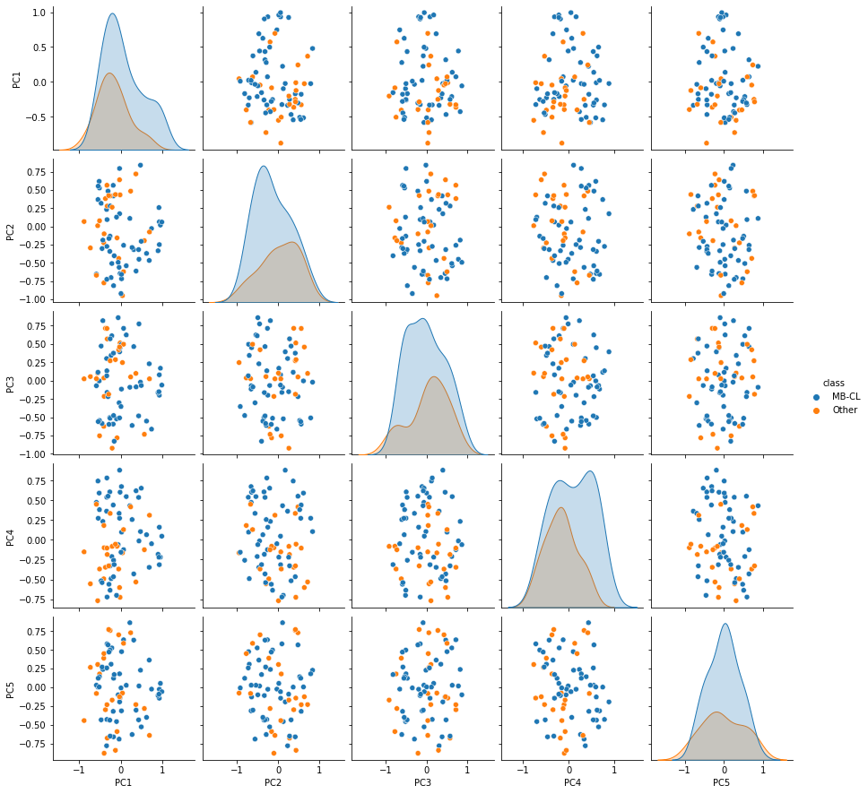

```python
X_PCA_visualize, pca = get_X_PCA(0.25, X_s)
sns.pairplot(data=X_PCA_visualize, hue='class')
```

Os **resultados obtidos** aqui no PCA, como ja era de prever depois de analisar os graficos dos scores, os resultados obtidos **nao diferem muito dos resultados visualizados para o X_variance**, querendo dizer com isto que **não conseguimos visualizar uma boa separação** dos dados para as top 5 componentes principais.

```python
# Definir colunas
cols = [X_cols, X_variance_cols, X_PCA_cols]

# Definir dfs
dfs = [X_s, X_variance, X_PCA]
```

## 3. Clustering Samples using Partitional Clustering

Use **`K`-means** to cluster the samples:

- Cluster the original data (54.675 features): **X**.
  - Use different values of `K`.
  - For each value of `K` present the clustering by specifying how many samples MB-CL and Other are in each cluster.  
    For instance, `{0: {'MB-CL': 51, 'Other': 0}, 1: {'MB-CL': 0, 'Other': 25}}` is the ideal clustering that we aimed at obtained with K-means when `K=2`, where the first cluster has 51 MB-CL samples and 0 Other samples and the second cluster has 0 MB-CL samples and 25 Other samples. You can choose how to output this information. **Tip**: You can explore the usage of contigency matrices.
  - What is the best value of `K` ? Justify using the clustering results and the [Silhouette score](http://scikit-learn.org/stable/modules/generated/sklearn.metrics.silhouette_score.html).
- Cluster the data obtained after removing features with low variance: **X_variance**.
  - Study different values of `K` as above.
- Cluster the data obtained after applying PCA: **X_PCA**.
  - Study different values of `K` as above.
- Compare the results obtained in the three datasets above for the best `K`.
- Discuss the results.

```python
clusters = initialize_cluster_variables(clusters = 6)
```

## 3.1 Clustering with k = [2-6]

```python
for k in range(0,5):
    for idx,df in enumerate(dfs):
        cluster, score = perform_Kmeans(df,cols[idx],k + 2)
        clusters[k]['0'].append(cluster[0])
        clusters[k]['1'].append(cluster[1])
        clusters[k]['score'].append(score['silhouette'])
        if k >= 1:
            clusters[k]['2'].append(cluster[2])
        if k >= 2:
            clusters[k]['3'].append(cluster[3])
        if k >= 3:
            clusters[k]['4'].append(cluster[4])
        if k >= 4:
            clusters[k]['5'].append(cluster[5])
```

## 3.2 Results

### K = 2

```python
kmeans_k2_df = pd.DataFrame(clusters[0]).T
kmeans_k2_df.columns = ['Raw_df', 'X_variance', 'X_PCA']
kmeans_k2_df.T
```

|  | 0 | 1 | score |
| --- | --- | --- | --- |
| Raw_df | {'MB-CL': 30, 'Other': 7} | {'MB-CL': 21, 'Other': 18} | 0.0504694 |
| X_variance | {'MB-CL': 11, 'Other': 10} | {'MB-CL': 40, 'Other': 15} | 0.238127 |
| X_PCA | {'MB-CL': 31, 'Other': 17} | {'MB-CL': 20, 'Other': 8} | 0.0355346 |

### K = 3

```python
kmeans_k3_df = pd.DataFrame(clusters[1]).T
kmeans_k3_df.columns = ['Raw_df', 'X_variance', 'X_PCA']
kmeans_k3_df.T
```

|  | 0 | 1 | 2 | score |
| --- | --- | --- | --- | --- |
| Raw_df | {'MB-CL': 16, 'Other': 14} | {'MB-CL': 23, 'Other': 7} | {'MB-CL': 12, 'Other': 4} | 0.0402385 |
| X_variance | {'MB-CL': 11, 'Other': 10} | {'MB-CL': 18, 'Other': 10} | {'MB-CL': 22, 'Other': 5} | 0.183073 |
| X_PCA | {'MB-CL': 25, 'Other': 10} | {'MB-CL': 13, 'Other': 8} | {'MB-CL': 13, 'Other': 7} | 0.043184 |

### K = 4

```python
kmeans_k4_df = pd.DataFrame(clusters[2]).T
kmeans_k4_df.columns = ['Raw_df', 'X_variance', 'X_PCA']
kmeans_k4_df.T
```

|  | 0 | 1 | 2 | 3 | score |
| --- | --- | --- | --- | --- | --- |
| Raw_df | {'MB-CL': 6, 'Other': 0} | {'MB-CL': 10, 'Other': 9} | {'MB-CL': 9, 'Other': 9} | {'MB-CL': 26, 'Other': 7} | 0.0466618 |
| X_variance | {'MB-CL': 23, 'Other': 5} | {'MB-CL': 8, 'Other': 0} | {'MB-CL': 17, 'Other': 12} | {'MB-CL': 3, 'Other': 8} | 0.23624 |
| X_PCA | {'MB-CL': 13, 'Other': 12} | {'MB-CL': 18, 'Other': 5} | {'MB-CL': 13, 'Other': 8} | {'MB-CL': 7, 'Other': 0} | 0.0638662 |

### K = 5

```python
kmeans_k5_df = pd.DataFrame(clusters[3]).T
kmeans_k5_df.columns = ['Raw_df', 'X_variance', 'X_PCA']
kmeans_k5_df.T
```

|  | 0 | 1 | 2 | 3 | 4 | score |
| --- | --- | --- | --- | --- | --- | --- |
| Raw_df | {'MB-CL': 0, 'Other': 1} | {'MB-CL': 7, 'Other': 10} | {'MB-CL': 33, 'Other': 7} | {'MB-CL': 3, 'Other': 7} | {'MB-CL': 8, 'Other': 0} | 0.062866 |
| X_variance | {'MB-CL': 19, 'Other': 4} | {'MB-CL': 3, 'Other': 8} | {'MB-CL': 13, 'Other': 4} | {'MB-CL': 8, 'Other': 9} | {'MB-CL': 8, 'Other': 0} | 0.197651 |
| X_PCA | {'MB-CL': 7, 'Other': 8} | {'MB-CL': 16, 'Other': 6} | {'MB-CL': 8, 'Other': 8} | {'MB-CL': 7, 'Other': 0} | {'MB-CL': 13, 'Other': 3} | 0.0791357 |

### K = 6

```python
kmeans_k6_df = pd.DataFrame(clusters[4]).T
kmeans_k6_df.columns = ['Raw_df', 'X_variance', 'X_PCA']
kmeans_k6_df.T
```

|  | 0 | 1 | 2 | 3 | 4 | 5 | score |
| --- | --- | --- | --- | --- | --- | --- | --- |
| Raw_df | {'MB-CL': 16, 'Other': 5} | {'MB-CL': 8, 'Other': 1} | {'MB-CL': 1, 'Other': 3} | {'MB-CL': 14, 'Other': 2} | {'MB-CL': 5, 'Other': 9} | {'MB-CL': 7, 'Other': 5} | 0.0419863 |
| X_variance | {'MB-CL': 3, 'Other': 8} | {'MB-CL': 4, 'Other': 2} | {'MB-CL': 19, 'Other': 4} | {'MB-CL': 6, 'Other': 8} | {'MB-CL': 8, 'Other': 0} | {'MB-CL': 11, 'Other': 3} | 0.187672 |
| X_PCA | {'MB-CL': 5, 'Other': 7} | {'MB-CL': 12, 'Other': 6} | {'MB-CL': 6, 'Other': 8} | {'MB-CL': 7, 'Other': 0} | {'MB-CL': 12, 'Other': 3} | {'MB-CL': 9, 'Other': 1} | 0.0874861 |

## 3.3 Analysing results

Para ser mais facil comparar os resultados dos modelos entre si, vamos olhar para o grafico abaixo, que mostra os diferentes *silhouette scores* dos modelos criados para cada um dos dataframes:

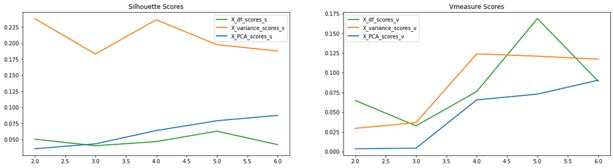

```python
plot_models('kmeans', 6, dfs, cols)
```

Olhando para o grafico, e facil visualizar que o dataframe **X_variance** obtem consistentemente melhores *silhouette scores* para qualquer valor de K, que os modelos criados para os outros dois *dataframes*.

Os melhores valores de K para cada *dataframe* segundo o *silhouette score* são:

- **X_df:** k = 5
- **X_variance:** k = 2 e k = 4
- **X_PCA:** k = 6

Vamos então analisar em detalhe estes valores de **K**:

```python
kmeans_k2_df.T
```

|  | 0 | 1 | score |
| --- | --- | --- | --- |
| Raw_df | {'MB-CL': 30, 'Other': 7} | {'MB-CL': 21, 'Other': 18} | 0.0504694 |
| X_variance | {'MB-CL': 11, 'Other': 10} | {'MB-CL': 40, 'Other': 15} | 0.238127 |
| X_PCA | {'MB-CL': 31, 'Other': 17} | {'MB-CL': 20, 'Other': 8} | 0.0355346 |

Para **k=2** conseguimos ver o seguinte:

- Todos os modelos encontrão um cluster um cluster no qual a maioria dos casos é da classe **MB-Cl**.
- O outro cluster apresenta proporções mais homogenias de ambas as classes

Olhando para estes resultados não conseguimos dizer que existem muitas diferenças entre os clusters criados para cada um dos dataframes, sem ser as proporções de instancias por cluster.

```python
kmeans_k4_df.T
```

|  | 0 | 1 | 2 | 3 | score |
| --- | --- | --- | --- | --- | --- |
| Raw_df | {'MB-CL': 6, 'Other': 0} | {'MB-CL': 10, 'Other': 9} | {'MB-CL': 9, 'Other': 9} | {'MB-CL': 26, 'Other': 7} | 0.0466618 |
| X_variance | {'MB-CL': 23, 'Other': 5} | {'MB-CL': 8, 'Other': 0} | {'MB-CL': 17, 'Other': 12} | {'MB-CL': 3, 'Other': 8} | 0.23624 |
| X_PCA | {'MB-CL': 13, 'Other': 12} | {'MB-CL': 18, 'Other': 5} | {'MB-CL': 13, 'Other': 8} | {'MB-CL': 7, 'Other': 0} | 0.0638662 |

Para **k = 4**, conseguimos verificar que todos os modelos tendem a encontrar um cluster com a maioria das instancias da classe MB_CL, um cluster puro e mais pequeno com instancias apenas da classe MB_CL e os restantes clusters apresentam conjuntos mais heterogeneos de instancias.

Os clusters criados para o dataframe X_variance destacam por, para além do referido acima, existe um cluster com mais instancias de Other do que de MB-CL (8-3)

Achamos que os clusters criados para o X_variance com k = 4 são melhores que os clusters apresentados para k = 2.

```python
kmeans_k5_df.T
```

|  | 0 | 1 | 2 | 3 | 4 | score |
| --- | --- | --- | --- | --- | --- | --- |
| Raw_df | {'MB-CL': 0, 'Other': 1} | {'MB-CL': 7, 'Other': 10} | {'MB-CL': 33, 'Other': 7} | {'MB-CL': 3, 'Other': 7} | {'MB-CL': 8, 'Other': 0} | 0.062866 |
| X_variance | {'MB-CL': 19, 'Other': 4} | {'MB-CL': 3, 'Other': 8} | {'MB-CL': 13, 'Other': 4} | {'MB-CL': 8, 'Other': 9} | {'MB-CL': 8, 'Other': 0} | 0.197651 |
| X_PCA | {'MB-CL': 7, 'Other': 8} | {'MB-CL': 16, 'Other': 6} | {'MB-CL': 8, 'Other': 8} | {'MB-CL': 7, 'Other': 0} | {'MB-CL': 13, 'Other': 3} | 0.0791357 |

Para **k = 5** vemos que os resultados são bastante semelhantes aos resultados apresentados para **k = 4**. Se olharmos para os diversos clusters, achamos até que, apesar de não ser o esperado, os clusters para o **X_df** aparentam ser melhores que os clusters para qualquer outro dataframe.

```python
kmeans_k6_df.T
```

|  | 0 | 1 | 2 | 3 | 4 | 5 | score |
| --- | --- | --- | --- | --- | --- | --- | --- |
| Raw_df | {'MB-CL': 16, 'Other': 5} | {'MB-CL': 8, 'Other': 1} | {'MB-CL': 1, 'Other': 3} | {'MB-CL': 14, 'Other': 2} | {'MB-CL': 5, 'Other': 9} | {'MB-CL': 7, 'Other': 5} | 0.0419863 |
| X_variance | {'MB-CL': 3, 'Other': 8} | {'MB-CL': 4, 'Other': 2} | {'MB-CL': 19, 'Other': 4} | {'MB-CL': 6, 'Other': 8} | {'MB-CL': 8, 'Other': 0} | {'MB-CL': 11, 'Other': 3} | 0.187672 |
| X_PCA | {'MB-CL': 5, 'Other': 7} | {'MB-CL': 12, 'Other': 6} | {'MB-CL': 6, 'Other': 8} | {'MB-CL': 7, 'Other': 0} | {'MB-CL': 12, 'Other': 3} | {'MB-CL': 9, 'Other': 1} | 0.0874861 |

#### Best Model

Por fim, resta-nos dizer que com esta analise conjunta entre clusters criados e silhouette score, vamos considerar o modelo criado para o **X_variance** com **k = 4** como o melhor modelo para o **K-means**.

#### Visualizing Kmeans vs Ground truth

Tal como vimos acima, no ponto 2, as classes não aparentam uma distinção clara nos dados, estando elas bastantes sobrepostas entre si, para todas das features com mais variancia. Os resultados fracos para o **kmeans** são justificaveis por este facto, bem pela forma como o algoritmo encontra os seus clusters. Como podemos ver abaixo, o algoritmo coloca no mesmo cluster pontos que se encontram perto entre si, no entanto, os grupos na realidade estão bastante mais sobrepostos.

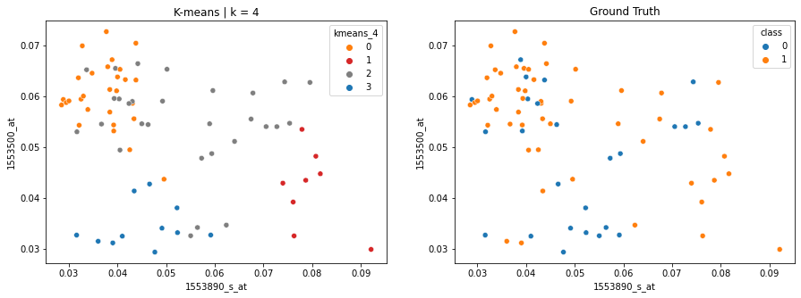

```python
fig, axs = plt.subplots(ncols=2,figsize=(15,5))
axs[0].set_title('K-means | k = 4')
axs[1].set_title('Ground Truth')
sns.scatterplot(data=X_variance, x='1553890_s_at', y='1553500_at', hue='kmeans_4', palette=['tab:orange','tab:red','tab:gray','tab:blue'], ax=axs[0])
sns.scatterplot(data=X_variance, x='1553890_s_at', y='1553500_at', hue='class', ax=axs[1])
plt.show()
```

Nos plots acima, temos:

- Cores quentes os pontos pertencentes a classe **MB-CL**, ou a um cluster nos quais esta classe é a maioria.
- Cores frias temos pontos pertencentes a classe **Other** ou a um cluster nos quais esta classe é a maioria.
- Cinzento os pontos pertencentes a um cluster heterogenio.

Olhando para os graficos conseguimos ver que o nosso melhor modelo é capaz de agrupar corretamente os pontos nos aglomerados mais densos (para estes eixos), mas tem dificuldades com a separação dos pontos mais dispersos.

## 4. Clustering Samples using Hierarchical Clustering

Use a **Hierarchical Clustering Algorithm (HCA)** to cluster the samples:

- Cluster the data in **X_variance**.
  - Use **different linkage metrics**.
  - Use different values of `K`.
  - For each linkage metric and value of `K` present the clustering by specifying how many MB-CL and Other samples are in each cluster as you did before.
  - What is the best linkage metric and the best value of `K`? Justify using the clustering results and the [Silhouette score](http://scikit-learn.org/stable/modules/generated/sklearn.metrics.silhouette_score.html).
- Cluster the data in **X_PCA**.
  - Study different linkage metrics and different values of `K` as above.
- Compare the results obtained in the two datasets above for the best linkage metric and the best `K`.
- Discuss the results

Visto que a analise é para ser feita apenas para os dataframes **X_PCA** e **X_variance**, vamos remover o **X_df** do nosso conjunto de dataframes

```python
# Definir dfs e cols
cols = [X_variance_cols, X_PCA_cols]
dfs = [X_variance, X_PCA]
```

Agora, a semelhança do que foi feito para o algoritmo **k-means** vamos criar os diversos clusters gerar os varios clusters para diferentes numeros de **Ks**, fazendo apenas agora o passo adicional de alterar o tipo de linkage.

## 4.1 Average Linkage

```python
n_clusters = 8
hca_average = initialize_cluster_variables(8)
```

```python
for k in range(2,n_clusters + 1):
    for idx,df in enumerate(dfs):
        cluster, score = perform_HCA(df, cols[idx], linkage = "average", n_clusters = k)
        hca_average[k-2]['0'].append(cluster[0])
        hca_average[k-2]['1'].append(cluster[1])
        hca_average[k-2]['score'].append(score['silhouette'])
        if k >= 3:
            hca_average[k-2]['2'].append(cluster[2])
        if k >= 4:
            hca_average[k-2]['3'].append(cluster[3])
        if k >= 5:
            hca_average[k-2]['4'].append(cluster[4])
        if k >= 6:
            hca_average[k-2]['5'].append(cluster[5])
        if k >= 7:
            hca_average[k-2]['6'].append(cluster[6])
        if k >= 8:
            hca_average[k-2]['7'].append(cluster[7])
        if k >= 9:
            hca_average[k-2]['8'].append(cluster[8])
```

### K = 2

```python
hca_average_k2_df = pd.DataFrame(hca_average[0]).T
hca_average_k2_df.columns = ['X_variance', 'X_PCA']
hca_average_k2_df.T
```

|  | 0 | 1 | score |
| --- | --- | --- | --- |
| X_variance | {'MB-CL': 43, 'Other': 25} | {'MB-CL': 8, 'Other': 0} | 0.243707 |
| X_PCA | {'MB-CL': 43, 'Other': 25} | {'MB-CL': 8, 'Other': 0} | 0.0515042 |

### K = 3

```python
hca_average_k3_df = pd.DataFrame(hca_average[1]).T
hca_average_k3_df.columns = ['X_variance', 'X_PCA']
hca_average_k3_df.T
```

|  | 0 | 1 | 2 | score |
| --- | --- | --- | --- | --- |
| X_variance | {'MB-CL': 3, 'Other': 8} | {'MB-CL': 8, 'Other': 0} | {'MB-CL': 40, 'Other': 17} | 0.276509 |
| X_PCA | {'MB-CL': 36, 'Other': 12} | {'MB-CL': 8, 'Other': 0} | {'MB-CL': 7, 'Other': 13} | 0.0580413 |

### K = 4

```python
hca_average_k4_df = pd.DataFrame(hca_average[2]).T
hca_average_k4_df.columns = ['X_variance', 'X_PCA']
hca_average_k4_df.T
```

|  | 0 | 1 | 2 | 3 | score |
| --- | --- | --- | --- | --- | --- |
| X_variance | {'MB-CL': 40, 'Other': 17} | {'MB-CL': 8, 'Other': 0} | {'MB-CL': 3, 'Other': 7} | {'MB-CL': 0, 'Other': 1} | 0.239174 |
| X_PCA | {'MB-CL': 7, 'Other': 13} | {'MB-CL': 8, 'Other': 0} | {'MB-CL': 26, 'Other': 10} | {'MB-CL': 10, 'Other': 2} | 0.0714597 |

### K = 5

```python
hca_average_k5_df = pd.DataFrame(hca_average[3]).T
hca_average_k5_df.columns = ['X_variance', 'X_PCA']
hca_average_k5_df.T
```

|  | 0 | 1 | 2 | 3 | 4 | score |
| --- | --- | --- | --- | --- | --- | --- |
| X_variance | {'MB-CL': 8, 'Other': 10} | {'MB-CL': 32, 'Other': 7} | {'MB-CL': 3, 'Other': 7} | {'MB-CL': 0, 'Other': 1} | {'MB-CL': 8, 'Other': 0} | 0.232896 |
| X_PCA | {'MB-CL': 26, 'Other': 10} | {'MB-CL': 8, 'Other': 0} | {'MB-CL': 3, 'Other': 8} | {'MB-CL': 10, 'Other': 2} | {'MB-CL': 4, 'Other': 5} | 0.080444 |

### K = 6

```python
hca_average_k6_df = pd.DataFrame(hca_average[4]).T
hca_average_k6_df.columns = ['X_variance', 'X_PCA']
hca_average_k6_df.T
```

|  | 0 | 1 | 2 | 3 | 4 | 5 | score |
| --- | --- | --- | --- | --- | --- | --- | --- |
| X_variance | {'MB-CL': 32, 'Other': 7} | {'MB-CL': 0, 'Other': 2} | {'MB-CL': 8, 'Other': 8} | {'MB-CL': 0, 'Other': 1} | {'MB-CL': 8, 'Other': 0} | {'MB-CL': 3, 'Other': 7} | 0.222094 |
| X_PCA | {'MB-CL': 3, 'Other': 8} | {'MB-CL': 8, 'Other': 0} | {'MB-CL': 16, 'Other': 8} | {'MB-CL': 10, 'Other': 2} | {'MB-CL': 4, 'Other': 5} | {'MB-CL': 10, 'Other': 2} | 0.0904367 |

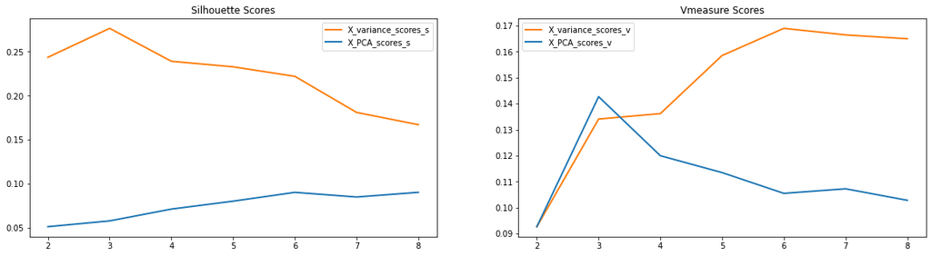

```python
plot_models('hca_average', n_clusters, dfs, cols)
```

### 4.2 Complete Linkage

```python
n_clusters = 8
hca_complete = initialize_cluster_variables(n_clusters)
```

```python
for k in range(2,n_clusters + 1):
    for idx,df in enumerate(dfs):
        cluster, score = perform_HCA(df, cols[idx], linkage = "complete", n_clusters = k)
        hca_complete[k-2]['0'].append(cluster[0])
        hca_complete[k-2]['1'].append(cluster[1])
        hca_complete[k-2]['score'].append(score['silhouette'])
        if k >= 3:
            hca_complete[k-2]['2'].append(cluster[2])
        if k >= 4:
            hca_complete[k-2]['3'].append(cluster[3])
        if k >= 5:
            hca_complete[k-2]['4'].append(cluster[4])
        if k >= 6:
            hca_complete[k-2]['5'].append(cluster[5])
        if k >= 7:
            hca_complete[k-2]['6'].append(cluster[6])
        if k >= 8:
            hca_complete[k-2]['7'].append(cluster[7])
        if k >= 9:
            hca_complete[k-2]['8'].append(cluster[8])
```

### K = 2

```python
hca_complete_k2_df = pd.DataFrame(hca_complete[0]).T
hca_complete_k2_df.columns = ['X_variance', 'X_PCA']
hca_complete_k2_df.T
```

|  | 0 | 1 | score |
| --- | --- | --- | --- |
| X_variance | {'MB-CL': 43, 'Other': 25} | {'MB-CL': 8, 'Other': 0} | 0.243707 |
| X_PCA | {'MB-CL': 33, 'Other': 12} | {'MB-CL': 18, 'Other': 13} | 0.0240759 |

### K = 3

```python
hca_complete_k3_df = pd.DataFrame(hca_complete[1]).T
hca_complete_k3_df.columns = ['X_variance', 'X_PCA']
hca_complete_k3_df.T
```

|  | 0 | 1 | 2 | score |
| --- | --- | --- | --- | --- |
| X_variance | {'MB-CL': 40, 'Other': 15} | {'MB-CL': 8, 'Other': 0} | {'MB-CL': 3, 'Other': 10} | 0.264157 |
| X_PCA | {'MB-CL': 18, 'Other': 13} | {'MB-CL': 26, 'Other': 11} | {'MB-CL': 7, 'Other': 1} | 0.0114073 |

### K = 4

```python
hca_complete_k4_df = pd.DataFrame(hca_complete[2]).T
hca_complete_k4_df.columns = ['X_variance', 'X_PCA']
hca_complete_k4_df.T
```

|  | 0 | 1 | 2 | 3 | score |
| --- | --- | --- | --- | --- | --- |
| X_variance | {'MB-CL': 3, 'Other': 10} | {'MB-CL': 8, 'Other': 8} | {'MB-CL': 32, 'Other': 7} | {'MB-CL': 8, 'Other': 0} | 0.237213 |
| X_PCA | {'MB-CL': 26, 'Other': 11} | {'MB-CL': 7, 'Other': 8} | {'MB-CL': 7, 'Other': 1} | {'MB-CL': 11, 'Other': 5} | 0.019802 |

### K = 5

```python
hca_complete_k5_df = pd.DataFrame(hca_complete[3]).T
hca_complete_k5_df.columns = ['X_variance', 'X_PCA']
hca_complete_k5_df.T
```

|  | 0 | 1 | 2 | 3 | 4 | score |
| --- | --- | --- | --- | --- | --- | --- |
| X_variance | {'MB-CL': 32, 'Other': 7} | {'MB-CL': 8, 'Other': 8} | {'MB-CL': 0, 'Other': 3} | {'MB-CL': 8, 'Other': 0} | {'MB-CL': 3, 'Other': 7} | 0.235139 |
| X_PCA | {'MB-CL': 17, 'Other': 10} | {'MB-CL': 7, 'Other': 8} | {'MB-CL': 7, 'Other': 1} | {'MB-CL': 11, 'Other': 5} | {'MB-CL': 9, 'Other': 1} | 0.0310689 |

### K = 6

```python
hca_complete_k6_df = pd.DataFrame(hca_complete[4]).T
hca_complete_k6_df.columns = ['X_variance', 'X_PCA']
hca_complete_k6_df.T
```

|  | 0 | 1 | 2 | 3 | 4 | 5 | score |
| --- | --- | --- | --- | --- | --- | --- | --- |
| X_variance | {'MB-CL': 0, 'Other': 3} | {'MB-CL': 8, 'Other': 8} | {'MB-CL': 12, 'Other': 3} | {'MB-CL': 8, 'Other': 0} | {'MB-CL': 3, 'Other': 7} | {'MB-CL': 20, 'Other': 4} | 0.183949 |
| X_PCA | {'MB-CL': 7, 'Other': 8} | {'MB-CL': 9, 'Other': 1} | {'MB-CL': 7, 'Other': 1} | {'MB-CL': 11, 'Other': 5} | {'MB-CL': 10, 'Other': 6} | {'MB-CL': 7, 'Other': 4} | 0.0423394 |

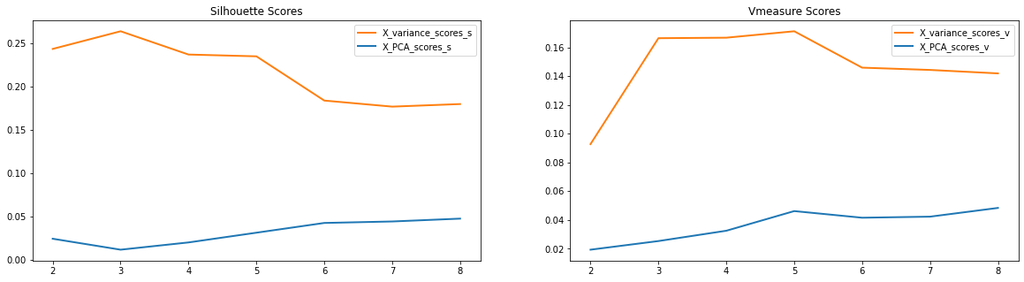

```python
plot_models('hca_complete', n_clusters, dfs, cols)
```

### 4.3 Single Linkage

```python
n_clusters = 8
hca_single = initialize_cluster_variables(n_clusters)
```

```python
for k in range(2,n_clusters + 1):
    for idx,df in enumerate(dfs):
        cluster, score = perform_HCA(df, cols[idx], linkage = "single", n_clusters = k)
        hca_single[k-2]['0'].append(cluster[0])
        hca_single[k-2]['1'].append(cluster[1])
        hca_single[k-2]['score'].append(score['silhouette'])
        if k >= 3:
            hca_single[k-2]['2'].append(cluster[2])
        if k >= 4:
            hca_single[k-2]['3'].append(cluster[3])
        if k >= 5:
            hca_single[k-2]['4'].append(cluster[4])
        if k >= 6:
            hca_single[k-2]['5'].append(cluster[5])
        if k >= 7:
            hca_single[k-2]['6'].append(cluster[6])
        if k >= 8:
            hca_single[k-2]['7'].append(cluster[7])
        if k >= 9:
            hca_single[k-2]['8'].append(cluster[8])
```

### K = 2

```python
hca_single_k2_df = pd.DataFrame(hca_single[0]).T
hca_single_k2_df.columns = ['X_variance', 'X_PCA']
hca_single_k2_df.T
```

|  | 0 | 1 | score |
| --- | --- | --- | --- |
| X_variance | {'MB-CL': 48, 'Other': 18} | {'MB-CL': 3, 'Other': 7} | 0.21187 |
| X_PCA | {'MB-CL': 50, 'Other': 25} | {'MB-CL': 1, 'Other': 0} | 0.0126074 |

### K = 3

```python
hca_single_k3_df = pd.DataFrame(hca_single[1]).T
hca_single_k3_df.columns = ['X_variance', 'X_PCA']
hca_single_k3_df.T
```

|  | 0 | 1 | 2 | score |
| --- | --- | --- | --- | --- |
| X_variance | {'MB-CL': 48, 'Other': 17} | {'MB-CL': 3, 'Other': 7} | {'MB-CL': 0, 'Other': 1} | 0.162037 |
| X_PCA | {'MB-CL': 49, 'Other': 25} | {'MB-CL': 1, 'Other': 0} | {'MB-CL': 1, 'Other': 0} | -0.0134297 |

### K = 4

```python
hca_single_k4_df = pd.DataFrame(hca_single[2]).T
hca_single_k4_df.columns = ['X_variance', 'X_PCA']
hca_single_k4_df.T
```

|  | 0 | 1 | 2 | 3 | score |
| --- | --- | --- | --- | --- | --- |
| X_variance | {'MB-CL': 40, 'Other': 17} | {'MB-CL': 3, 'Other': 7} | {'MB-CL': 0, 'Other': 1} | {'MB-CL': 8, 'Other': 0} | 0.239174 |
| X_PCA | {'MB-CL': 49, 'Other': 24} | {'MB-CL': 1, 'Other': 0} | {'MB-CL': 1, 'Other': 0} | {'MB-CL': 0, 'Other': 1} | -0.0237137 |

### K = 5

```python
hca_single_k5_df = pd.DataFrame(hca_single[3]).T
hca_single_k5_df.columns = ['X_variance', 'X_PCA']
hca_single_k5_df.T
```

|  | 0 | 1 | 2 | 3 | 4 | score |
| --- | --- | --- | --- | --- | --- | --- |
| X_variance | {'MB-CL': 40, 'Other': 16} | {'MB-CL': 3, 'Other': 7} | {'MB-CL': 0, 'Other': 1} | {'MB-CL': 8, 'Other': 0} | {'MB-CL': 0, 'Other': 1} | 0.192959 |
| X_PCA | {'MB-CL': 49, 'Other': 23} | {'MB-CL': 1, 'Other': 0} | {'MB-CL': 1, 'Other': 0} | {'MB-CL': 0, 'Other': 1} | {'MB-CL': 0, 'Other': 1} | -0.0329045 |

### K = 6

```python
hca_single_k6_df = pd.DataFrame(hca_single[4]).T
hca_single_k6_df.columns = ['X_variance', 'X_PCA']
hca_single_k6_df.T
```

|  | 0 | 1 | 2 | 3 | 4 | 5 | score |
| --- | --- | --- | --- | --- | --- | --- | --- |
| X_variance | {'MB-CL': 40, 'Other': 15} | {'MB-CL': 3, 'Other': 7} | {'MB-CL': 0, 'Other': 1} | {'MB-CL': 8, 'Other': 0} | {'MB-CL': 0, 'Other': 1} | {'MB-CL': 0, 'Other': 1} | 0.158489 |
| X_PCA | {'MB-CL': 48, 'Other': 23} | {'MB-CL': 1, 'Other': 0} | {'MB-CL': 1, 'Other': 0} | {'MB-CL': 0, 'Other': 1} | {'MB-CL': 0, 'Other': 1} | {'MB-CL': 1, 'Other': 0} | -0.0353166 |

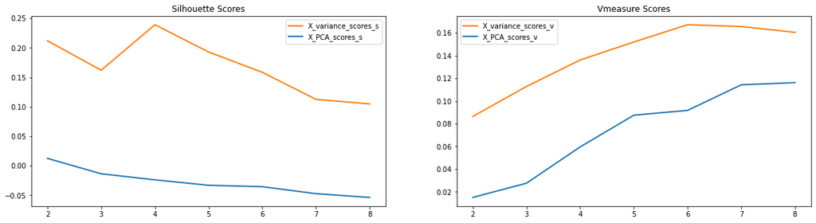

```python
plot_models('hca_single', n_clusters, dfs, cols)
```

### 4.4 Ward Linkage

```python
hca_ward = initialize_cluster_variables(8)
```

```python
for k in range(2,8 + 1):
    for idx,df in enumerate(dfs):
        cluster, score = perform_HCA(df, cols[idx], linkage = "ward", n_clusters = k)
        hca_ward[k-2]['0'].append(cluster[0])
        hca_ward[k-2]['1'].append(cluster[1])
        hca_ward[k-2]['score'].append(score['silhouette'])
        if k >= 3:
            hca_ward[k-2]['2'].append(cluster[2])
        if k >= 4:
            hca_ward[k-2]['3'].append(cluster[3])
        if k >= 5:
            hca_ward[k-2]['4'].append(cluster[4])
        if k >= 6:
            hca_ward[k-2]['5'].append(cluster[5])
        if k >= 7:
            hca_ward[k-2]['6'].append(cluster[6])
        if k >= 8:
            hca_ward[k-2]['7'].append(cluster[7])
        if k >= 9:
            hca_ward[k-2]['8'].append(cluster[8])
```

### K = 2

```python
hca_ward_k2_df = pd.DataFrame(hca_ward[0]).T
hca_ward_k2_df.columns = ['X_variance', 'X_PCA']
hca_ward_k2_df.T
```

|  | 0 | 1 | score |
| --- | --- | --- | --- |
| X_variance | {'MB-CL': 40, 'Other': 18} | {'MB-CL': 11, 'Other': 7} | 0.243277 |
| X_PCA | {'MB-CL': 44, 'Other': 25} | {'MB-CL': 7, 'Other': 0} | 0.0562729 |

### K = 3

```python
hca_ward_k3_df = pd.DataFrame(hca_ward[1]).T
hca_ward_k3_df.columns = ['X_variance', 'X_PCA']
hca_ward_k3_df.T
```

|  | 0 | 1 | 2 | score |
| --- | --- | --- | --- | --- |
| X_variance | {'MB-CL': 11, 'Other': 7} | {'MB-CL': 23, 'Other': 14} | {'MB-CL': 17, 'Other': 4} | 0.167292 |
| X_PCA | {'MB-CL': 31, 'Other': 21} | {'MB-CL': 7, 'Other': 0} | {'MB-CL': 13, 'Other': 4} | 0.0655918 |

### K = 4

```python
hca_ward_k4_df = pd.DataFrame(hca_ward[2]).T
hca_ward_k4_df.columns = ['X_variance', 'X_PCA']
hca_ward_k4_df.T
```

|  | 0 | 1 | 2 | 3 | score |
| --- | --- | --- | --- | --- | --- |
| X_variance | {'MB-CL': 23, 'Other': 14} | {'MB-CL': 3, 'Other': 7} | {'MB-CL': 17, 'Other': 4} | {'MB-CL': 8, 'Other': 0} | 0.218571 |
| X_PCA | {'MB-CL': 28, 'Other': 16} | {'MB-CL': 3, 'Other': 5} | {'MB-CL': 13, 'Other': 4} | {'MB-CL': 7, 'Other': 0} | 0.0792105 |

### K = 5

```python
hca_ward_k5_df = pd.DataFrame(hca_ward[3]).T
hca_ward_k5_df.columns = ['X_variance', 'X_PCA']
hca_ward_k5_df.T
```

|  | 0 | 1 | 2 | 3 | 4 | score |
| --- | --- | --- | --- | --- | --- | --- |
| X_variance | {'MB-CL': 16, 'Other': 7} | {'MB-CL': 7, 'Other': 7} | {'MB-CL': 17, 'Other': 4} | {'MB-CL': 8, 'Other': 0} | {'MB-CL': 3, 'Other': 7} | 0.19267 |
| X_PCA | {'MB-CL': 13, 'Other': 4} | {'MB-CL': 6, 'Other': 1} | {'MB-CL': 22, 'Other': 15} | {'MB-CL': 7, 'Other': 0} | {'MB-CL': 3, 'Other': 5} | 0.0899637 |

### K = 6

```python
hca_ward_k6_df = pd.DataFrame(hca_ward[4]).T
hca_ward_k6_df.columns = ['X_variance', 'X_PCA']
hca_ward_k6_df.T
```

|  | 0 | 1 | 2 | 3 | 4 | 5 | score |
| --- | --- | --- | --- | --- | --- | --- | --- |
| X_variance | {'MB-CL': 7, 'Other': 7} | {'MB-CL': 3, 'Other': 7} | {'MB-CL': 17, 'Other': 4} | {'MB-CL': 8, 'Other': 0} | {'MB-CL': 16, 'Other': 4} | {'MB-CL': 0, 'Other': 3} | 0.181046 |
| X_PCA | {'MB-CL': 22, 'Other': 15} | {'MB-CL': 6, 'Other': 1} | {'MB-CL': 9, 'Other': 2} | {'MB-CL': 7, 'Other': 0} | {'MB-CL': 3, 'Other': 5} | {'MB-CL': 4, 'Other': 2} | 0.0886515 |

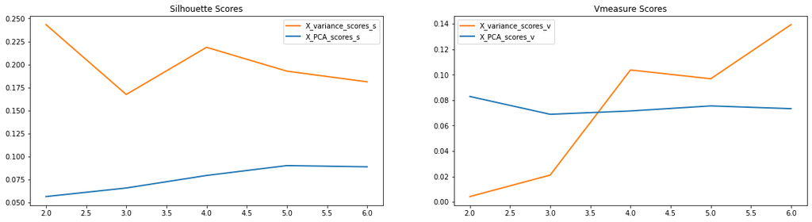

```python
plot_models('hca_ward', 6, dfs, cols)
```

### 4.5 Discussion

Para identificar quais os melhores metodos de clustering, bem como o numero de clusters, vamos olhar para os graficos abaixo no qual estão destacados os melhores modelos para cada um dos tipos de scores:

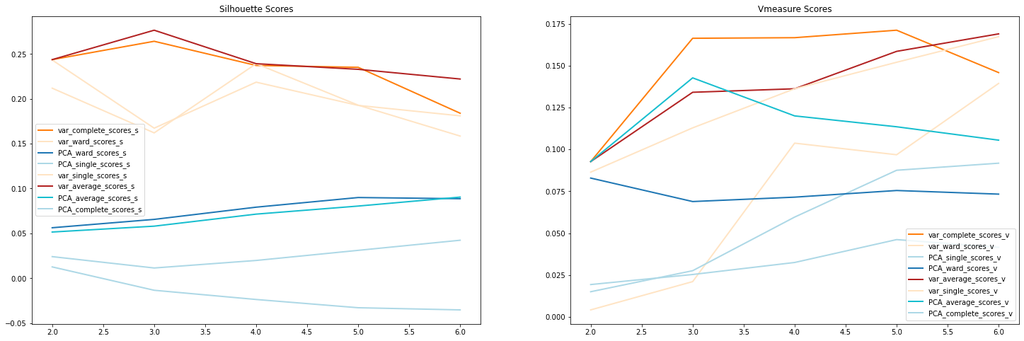

```python
plot_hca_models(6)
```

Com estes dois plots conseguimos visualizar bem os silhouette scores no plot mais a esquerda, bem como ter uma overview dos varios clusters para cada uma das linkages. Em cada um destes plots temos os modelos para o **X_variance** representados a **cores quentes**, e os modelos para o **X_PCA** a **cores frias**.

Em termos de silhuette scores, conseguimos ver que os modelos aplicados ao dataframe **X_variance** obtêm resultados consistentemente melhores que os modelos aplicados ao **X_PCA**. Temos que:

- Melhor modelo para **X_variance**: HC com **average linkage** e **K = 3**
- Melhor modelo para **X_PCA**: HC com **average ward** e **K = 5** Para esta metrica os modelos os melhores modelos para **X_variance** aparentam ter mais dificuldades na criação de clusters bem separados espacialmente, com o aumento do numero de clusters, enquanto que para o dataframe **X_PCA** verificamos o contrario. Isto pode ser devido ao facto de no primeiro termos mais features, e com o aumento do numero de clusters, estes sofrem cada vez mais influencia de features que possivelmente separam pior os dados espacialmente.

Olhando agora para a constituição dos clusters propriamente dita, vemos que os clusters com um melhor agrupamento das classes reais são:

Fazendo então uma conjugação destes dois criterios resta-nos definir então qual é o melhor modelo *overall* para ambos os datasets:

Comparando então os resultados dos melhores modelos para ambos os dataframes:

```python
hca_average_k3_df = hca_average_k3_df.T
hca_complete_k3_df = hca_complete_k3_df.T

X_var_complete = pd.DataFrame(hca_complete_k3_df.iloc[0])
X_PCA_average = pd.DataFrame(hca_average_k3_df.iloc[1])

X_var_complete = X_var_complete.rename(columns = {'X_variance': 'X_var_complete'})
X_PCA_average = X_PCA_average.rename(columns = {'X_PCA': 'X_PCA_average'})

compare_results = pd.concat([X_var_complete, X_PCA_average],axis=1)
compare_results.T
```

|  | 0 | 1 | 2 | score |
| --- | --- | --- | --- | --- |
| X_var_complete | {'MB-CL': 40, 'Other': 15} | {'MB-CL': 8, 'Other': 0} | {'MB-CL': 3, 'Other': 10} | 0.264157 |
| X_PCA_average | {'MB-CL': 36, 'Other': 12} | {'MB-CL': 8, 'Other': 0} | {'MB-CL': 7, 'Other': 13} | 0.0580413 |

Fazendo uma analise do dataframe acima, conseguimos ver que ambos os melhores para cada um dos dataframes definem clusters com constituições semelhantes:

- Ambos identificam um grande cluster com a grande maioria das instancias totais dos nossos dados. Neste cluster são identificados a grande maioria dos pontos da classe MB-CL.
- Ambos encontram um cluster puro com apenas pontos da classe MB-CL.
- Ambos encontram um cluster com a maioria dos pontos correspondentes a classe **Other**.

As unicas diferenças econtradas estão nas proporções dos clusters descritos no primeiro e terceiro ponto.

#### Visualizar os resultados

Com tudo isto discutido, vamos olhar abaixo para alguns plots de duas dimensões, numa tentativa de visualizar os clusters criados pelos nossos melhores modelos, e os clusters reais.

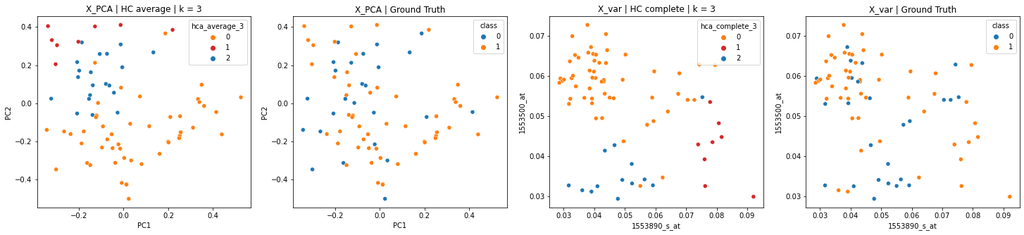

```python
fig, axs = plt.subplots(ncols=4,figsize=(25,5))
axs[0].set_title('X_PCA | HC average | k = 3')
axs[1].set_title('X_PCA | Ground Truth')
axs[2].set_title('X_var | HC complete | k = 3')
axs[3].set_title('X_var | Ground Truth')
sns.scatterplot(data=X_PCA, x='PC1', y='PC2', hue='hca_average_3', palette=['tab:orange','tab:red','tab:blue'], ax=axs[0])
sns.scatterplot(data=X_PCA, x='PC1', y='PC2', hue='class', ax=axs[1])
sns.scatterplot(data=X_variance, x='1553890_s_at', y='1553500_at', hue='hca_complete_3', palette=['tab:orange','tab:red','tab:blue'], ax=axs[2])
sns.scatterplot(data=X_variance, x='1553890_s_at', y='1553500_at', hue='class', ax=axs[3])
plt.show()
```

Nos plots acima, temos:

- Cores quentes os pontos pertencentes a classe **MB-CL**, ou a um cluster nos quais esta classe é a maioria.
- Cores frias temos pontos pertencentes a classe **Other** ou a um cluster nos quas esta classe é a maioria.

Se olharmos para os plots acima conseguimos então visualizar graficamente, o que ja tinhamos anteriormente inferido: Os algoritmos têm dificuldade em classificar os pontos que se encontram sobrepostos. Por exemplo, se olharmos para os plots referentes ao **X_PCA**, conseguimos ver que o modelo consegue identificar bem os pontos mais acima pertencentes a classe **MB-CL**, e agrupa bem uma boa porção dos pontos da classe **Other** no cluster mais abaixo, mas falhar a separar os pontos mais disperos da classe **Other** colocando-os juntos com o maior cluster (cluster laranja).

## 5. Evaluating Clustering Results

In this task you should compare the best results obtained using `K`-means and HCA

1. **Without using ground truth**
2. **Using ground truth (`Medulloblastoma Type`)**.

### 5.1. Without Using Ground Truth

**Choose one adequate measure** from those available by Sciki-learn (https://scikit-learn.org/stable/modules/clustering.html#clustering-performance-evaluation) to evaluate the different clusterings.

Escolhemos: **Silhouette Score**

Voltado aos pontos anteriores, identificamos os seguinte modelos com melhor *silhouette score*:

- `Kmeans`: k = 4 para **X_variance**
- `Hierarchical clustering`: *average linkage* com K = 3 para **X_variance**

Os seus scores foram os seguintes:

```python
scores_s = { 'Silhuette': [get_silhuette_score(X_variance,X_variance_cols,'kmeans_4'),get_silhuette_score(X_variance,X_variance_cols,'hca_average_3')],
             'Models': ['Kmeans_k4','Hca_average_k3']}

scores_s_df = pd.DataFrame(scores_s)
scores_s_df
```

|  | Silhuette | Models |
| --- | --- | --- |
| 0 | 0.236240 | Kmeans_k4 |
| 1 | 0.276509 | Hca_average_k3 |

Conseguimos ver que o modelo **Hca_average_k3** apresenta melhores resultados que o **Kmeans_k4**, e consegue-o utilizando menos clusters. A diferença entre os modelos, apesar de notavél não é astronomica, portanto, para visualizar melhor o desempenho dos modelos e podermos compara-los de uma melhor forma, vamos olhar para as suas matrizes de contingencias e alguns plots dos clusters reais VS clusters criados.

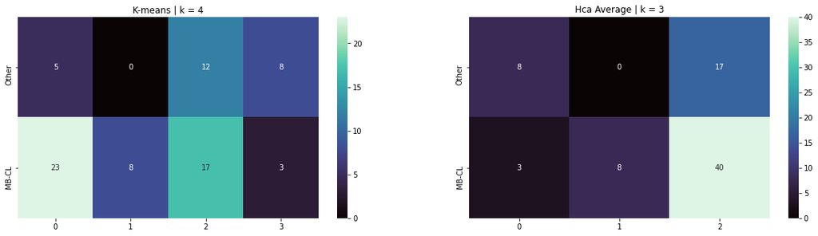

```python
fig, axs = plt.subplots(ncols=2,figsize=(20,5))
axs[0].set_title('K-means | k = 4')
axs[1].set_title('Hca Average | k = 3')
sns.heatmap(contingency_matrix(X_variance['class'], X_variance['kmeans_4']), annot=True, fmt="d",  cmap="mako", yticklabels = ['Other','MB-CL'],ax=axs[0])
sns.heatmap(contingency_matrix(X_variance['class'], X_variance['hca_average_3']), annot=True, fmt="d",  cmap="mako", yticklabels = ['Other','MB-CL'],ax=axs[1])
plt.show()
```

Começando pelas matrizes de contingencia, é importante notar que

- Numa matriz perfeita teriamos sempre clusters puros, ou seja, uma das linhas teria sempre de apresentar valor 0 para qualquer coluna.
- Clusters bons refletem sempre grandes contrastes de cor entre as linhas para qualquer dada coluna.

Olhando para as matrizes dos nossos dois modelos conseguimos ver que ambos obtêm resultados iguais, no que toca a identificação de um cluster puro da classe `MB-CL` (Other:0 - MB-CL:8) e de outro com a maioria da classe `Other` (Other:8 - MB-CL:3). A grande diferença entre estes dois modelos é que:

- Enquanto que o modelo **HCA Average | k = 3** cria um cluster maior, no qual tem todos os pontos restantes (Other:17 - MB-CL:40), ficando assim com um cluster que para cada instancia da classe `0` existem cerca de duas da classe `1`
- O modelo **K-means | k = 4** cria dois clusters, sendo um deles bastante puro para classe `MB-CL` (Other:5 - MB-CL:23), e o outro bastante internamente heterogenio (Other:12 - MB-CL:17).

Para visualizar as diferenças dos clusters espacialmente, podemos olhar para os plots abaixo:

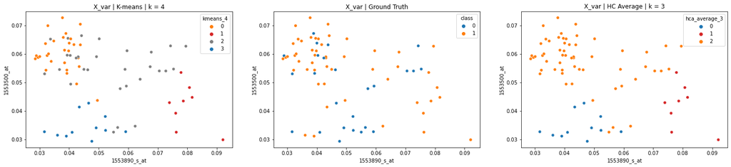

```python
fig, axs = plt.subplots(ncols=3,figsize=(25,5))
axs[0].set_title('X_var | K-means | k = 4')
axs[1].set_title('X_var | Ground Truth')
axs[2].set_title('X_var | HC Average | k = 3')
sns.scatterplot(data=X_variance, x='1553890_s_at', y='1553500_at', hue='kmeans_4', palette=['tab:orange','tab:red', 'gray','tab:blue'], ax=axs[0])
sns.scatterplot(data=X_variance, x='1553890_s_at', y='1553500_at', hue='class', ax=axs[1])
sns.scatterplot(data=X_variance, x='1553890_s_at', y='1553500_at', hue='hca_average_3', palette=['tab:blue','tab:red','tab:orange'], ax=axs[2])
plt.show()
```

Acima conseguimos ver então que os clusters identificados a cor pelo modelo **k-means** coincidem bastante bem com os pontos reais, no entanto existe o cluster cinzento que agrupa mal os pontos das duas classes. O metodo de **Hca com average linkage** não faz esta separação, agrupando todos estes pontos num unico cluster (laranja).